# Mapping CAC susceptibility loci to bulk RNAseq in carotid plaques.

A ‘druggable-MI-targets’ project

[Sander W. van der Laan, PhD](https://swvanderlaan.github.io) | @swvanderlaan

2021-03-11

*Clean the environment.*

*Set locations, and the working directory …*

```
Defining phenotypes and datasets.

Create a new analysis directory, including subdirectories.
[1] FALSE
[1] FALSE
[1] FALSE
[1] FALSE

Setting working directory and listing its contents.
[1] "/Users/slaan3/OneDrive - UMC Utrecht/PLINK/analyses/lookups/AE_20200512_COL_MKAVOUSI_MBOS_CHARGE_1000G_CAC/bulkRNAseq"
[1] "AERNA"                  "bulkRNAseq.nb.html"     "bulkRNAseq.Rmd"         "cemitool_trial_Reports" "cemitool_trial.nb.html" "cemitool_trial.Rmd"
[7] "obsolete_code.nb.html"  "obsolete_code.Rmd"
```

*… a package-installation function …*

*… and load those packages.*

```
* Genomic packages...
```

*We will create a datestamp and define the Utrecht Science Park Colour Scheme*.

# 1 ERA-CVD ‘druggable-MI-targets’

Plaque samples are derived from carotid endarterectomies as part of the Athero-Express Biobank Study which is an ongoing study in the UMC Utrecht.

# 2 Background

- IndSigSNPsforSander.xlsx
- GeneList_15042020.xlsx

```r
library(openxlsx)

# old list
# CAC_gene_list <- read.xlsx(paste0(TARGET_loc, "/GeneList_15042020.xlsx"))

# update list
CAC_gene_list <- read.xlsx(paste0(TARGET_loc, "/20210127_Overview_Genes_MMBos_Sander.xlsx"))

CAC_variants <- read.xlsx(paste0(TARGET_loc, "/IndSigSNPsforSander.xlsx"))

DT::datatable(CAC_gene_list)
```

|  | ensg | symbol | chr | start | end | positionalMapping | eqtlMapping | ciMapping | MAGMA | colocAOR | colocMAM | cardiogram5e-8 | cardiogram5e-5 |
| --- | --- | --- | --- | --- | --- | --- | --- | --- | --- | --- | --- | --- | --- |
| 1 | ENSG00000233539 | AC011294.3 | 7 | 46713383 | 46799449 | No | No | Yes | No | No | No | No | No |
| 2 | ENSG00000136378 | ADAMTS7 | 15 | 79051545 | 79103773 | Yes | Yes | No | Yes | No | Yes | Yes | Yes |
| 3 | ENSG00000163638 | ADAMTS9 | 3 | 64500333 | 64675676 | No | No | No | No | Yes | Yes | No | No |
| 4 | ENSG00000241158 | ADAMTS9-AS1 | 3 | 64547014 | 64575765 | No | No | No | No | Yes | No | No | No |
| 5 | ENSG00000241684 | ADAMTS9-AS2 | 3 | 64670546 | 64997143 | No | No | No | No | No | Yes | No | No |
| 6 | ENSG00000156110 | ADK | 10 | 75910960 | 76469061 | Yes | Yes | Yes | Yes | No | No | No | No |
| 7 | ENSG00000269515 | AL137026.1 | 10 | 44873687 | 44878739 | No | No | Yes | No | No | No | No | No |
| 8 | ENSG00000185009 | AP3M1 | 10 | 75881524 | 75910821 | Yes | No | Yes | Yes | No | No | No | No |
| 9 | ENSG00000130208 | APOC1 | 19 | 45417504 | 45422606 | Yes | No | No | No | No | No | Yes | Yes |
| 10 | ENSG00000130203 | APOE | 19 | 45409011 | 45412650 | Yes | No | No | Yes | No | No | Yes | Yes |

[output cut: 56 more lines]

```r
DT::datatable(CAC_variants)
```

|  | uniqID | rsID | variantid | chr | pos |
| --- | --- | --- | --- | --- | --- |
| 1 | 6:12768218:C:T | rs12202891 | 6:12768218 | 6 | 12768218 |
| 2 | 6:12801967:A:C | rs9381401 | 6:12801967 | 6 | 12801967 |
| 3 | 6:12883524:A:C | rs13208248 | 6:12883524 | 6 | 12883524 |
| 4 | 6:12887465:A:G | rs10456561 | 6:12887465 | 6 | 12887465 |
| 5 | 6:12891103:G:T | rs35355695 | 6:12891103 | 6 | 12891103 |
| 6 | 6:12892486:A:G | rs6925904 | 6:12892486 | 6 | 12892486 |
| 7 | 6:12903957:A:G | rs9349379 | 6:12903957 | 6 | 12903957 |
| 8 | 6:12919867:A:G | rs2876303 | 6:12919867 | 6 | 12919867 |
| 9 | 6:12921714:A:T | rs111395058 | 6:12921714 | 6 | 12921714 |
| 10 | 6:12943066:A:G | rs13201878 | 6:12943066 | 6 | 12943066 |

[output cut: 35 more lines]

```r
NA
```

```r
CAC_target_genes <- unlist(CAC_gene_list$symbol)
CAC_target_genes
```

```
 [1] "AC011294.3"   "ADAMTS7"      "ADAMTS9"      "ADAMTS9-AS1"  "ADAMTS9-AS2"  "ADK"          "AL137026.1"   "AP3M1"        "APOC1"        "APOE"         "ARID5B"
[12] "ATP2B1"       "BCAM"         "BCAR1"        "C6orf195"     "C9orf53"      "CAMK2G"       "CDKN2A"       "CDKN2B"       "CHRNA5"       "CHRNB4"       "COL4A1"
[23] "COL4A2"       "COMT"         "COMTD1"       "CTSH"         "DUPD1"        "DUSP13"       "EDN1"         "ENPP1"        "ENPP3"        "ESYT3"        "FGF23"
[34] "FHL5"         "GFOD1"        "GGCX"         "HELLS"        "HHIPL1"       "IGFBP3"       "KAT6B"        "KIAA1462"     "KRT8P46"      "LINC00472"    "LPGAT1"
[45] "LRRC37A15P"   "MAT2A"        "MORF4L1"      "MRAS"         "MTAP"         "PDGFD"        "PHACTR1"      "PRKAR2B"      "PVRL2"        "RP11-145E5.5" "RP1-257A7.4"
[56] "RP1-257A7.5"  "RTKN2"        "SAMD8"        "SMG6"         "TBC1D7"       "TOMM40"       "VCL"          "VDAC2"        "ZFHX4"        "ZNF32"        "ZNF485"
```

```r
target_genes = CAC_target_genes
```

# 3 Load data

First we will load the data:

- bulk RNA sequencing (RNAseq) experimental data from carotid plaques
- Athero-Express clinical data.

## 3.1 Bulk RNAseq data

Here we load the latest dataset from our Athero-Express bulk RNA experiment d.d. 2019-12-11 mapped to b37 and Ensembl 87.

These bulk RNAseq data are filtered and corrected:

- UMI corrected
- unmappable genes are excluded

```r
# bulk RNAseq data
bulkRNA_counts <- fread(paste0(AERNA_loc,"/2019-12-11_bulk_RNAseq_data_to_share/bulk_RNAseq_raw_counts_UMIcorr_weird_genes_filtered.txt"))
```

```
|--------------------------------------------------|
|==================================================|
```

```r
# batch information
bulkRNA_meta <- fread(paste0(AERNA_loc,"/2019-12-11_bulk_RNAseq_data_to_share/bulk_RNAseq_metadata.txt"))
```

Quick peek at the counts and meta-data of the RNAseq experiment.

```r
head(bulkRNA_counts)
```

| ensembl_gene_id | symbol | chr | start | end | strand | ae1 | ae1026 | ae1029 | ae1032 | ae1035 | ae1054 | ae1055 | ae1066 | ae107 | ae1074 | ae1082 | ae1100 | ae112 | ae1122 | ae113 | ae1139 | ae114 | ae1140 | ae1155 | ae1157 | ae116 | ae1160 | ae117 | ae1173 | … |
| --- | --- | --- | --- | --- | --- | --- | --- | --- | --- | --- | --- | --- | --- | --- | --- | --- | --- | --- | --- | --- | --- | --- | --- | --- | --- | --- | --- | --- | --- | --- |
| ENSG00000184389 | A3GALT2 | 01 | 33772367 | 33786699 | - | 0 | 0 | 0 | 0 | 0 | 0 | 0 | 0 | 0 | 0 | 0 | 0 | 0 | 0 | 0 | 0 | 0 | 0 | 0 | 0 | 0 | 0 | 0 | 0 | … |
| ENSG00000188984 | AADACL3 | 01 | 12776118 | 12788726 | + | 1 | 0 | 0 | 0 | 0 | 0 | 0 | 0 | 0 | 0 | 0 | 0 | 0 | 0 | 0 | 0 | 0 | 0 | 0 | 0 | 0 | 0 | 0 | 0 | … |
| ENSG00000204518 | AADACL4 | 01 | 12704566 | 12727097 | + | 0 | 0 | 0 | 0 | 0 | 0 | 0 | 0 | 0 | 0 | 1 | 0 | 0 | 0 | 0 | 0 | 0 | 0 | 0 | 0 | 0 | 0 | 0 | 0 | … |
| ENSG00000198691 | ABCA4 | 01 | 94458393 | 94586688 | - | 0 | 1 | 0 | 0 | 0 | 0 | 0 | 0 | 0 | 0 | 0 | 0 | 0 | 0 | 1 | 0 | 0 | 0 | 0 | 4 | 0 | 0 | 0 | 1 | … |
| ENSG00000135776 | ABCB10 | 01 | 229652329 | 229694442 | - | 0 | 0 | 0 | 0 | 0 | 0 | 2 | 0 | 0 | 0 | 0 | 1 | 0 | 2 | 2 | 1 | 0 | 0 | 0 | 1 | 0 | 0 | 0 | 13 | … |
| ENSG00000117528 | ABCD3 | 01 | 94883933 | 94984222 | + | 2 | 2 | 3 | 0 | 0 | 1 | 4 | 3 | 1 | 5 | 0 | 17 | 1 | 1 | 2 | 2 | 3 | 0 | 0 | 4 | 0 | 0 | 3 | 57 | … |

```r
head(bulkRNA_meta)
```

| study_number | batch | batchnr | pool |
| --- | --- | --- | --- |
| ae1 | 10 | 3219 | 9 |
| ae1026 | 3 | 3212 | 8 |
| ae1029 | 4 | 3213 | 3 |
| ae1032 | 6 | 3215 | 3 |
| ae1035 | 1 | 3210 | 5 |
| ae1054 | 6 | 3215 | 9 |

## 3.2 Clinical data

Loading Athero-Express clinical data.

```r
require(haven)

# AEDB <- haven::read_sav(paste0(AEDB_loc, "/2019-3NEW_AtheroExpressDatabase_ScientificAE_02072019_IC_added.sav"))
AEDB <- haven::read_sav(paste0(AEDB_loc, "/2020_1_NEW_AtheroExpressDatabase_ScientificAE_16-03-2020.sav"))
```

### 3.2.1 Fix STUDY_NUMBER

We will fix the `STUDY_NUMBER` to match the bulkRNAseq data.

```r
AEDB$STUDY_NUMBER <- paste0("ae", AEDB$STUDY_NUMBER)
head(AEDB$STUDY_NUMBER)
```

```
[1] "ae3"  "ae7"  "ae9"  "ae10" "ae12" "ae13"
```

### 3.2.2 Fixing and creating variables

We need to be very strict in defining *symptoms.* Therefore we will fix a new variable that groups *symptoms* at inclusion.

Coding of *symptoms* is as follows:

- missing -999
- Asymptomatic 0
- TIA 1
- minor stroke 2
- Major stroke 3
- Amaurosis fugax 4
- Four vessel disease 5
- Vertebrobasilary TIA 7
- Retinal infarction 8
- Symptomatic, but aspecific symtoms 9
- Contralateral symptomatic occlusion 10
- retinal infarction 11
- armclaudication due to occlusion subclavian artery, CEA needed for bypass 12
- retinal infarction + TIAs 13
- Ocular ischemic syndrome 14
- ischemisch glaucoom 15
- subclavian steal syndrome 16
- TGA 17

We will group as follows in `Symptoms.5G`:

1. Asymptomatic > 0
2. TIA > 1, 7, 13
3. Stroke > 2, 3
4. Ocular > 4, 14, 15
5. Retinal infarction > 8, 11
6. Other > 5, 9, 10, 12, 16, 17

We will also group as follows in `AsymptSympt`:

1. Asymptomatic > 0
2. TIA > 1, 7, 13 + Stroke > 2, 3
3. Ocular > 4, 14, 15 + Retinal infarction > 8, 11 + Other > 5, 9, 10, 12, 16, 17

We will also group as follows in `AsymptSympt2G`:

1. Asymptomatic > 0
2. TIA > 1, 7, 13 + Stroke > 2, 3 Ocular > 4, 14, 15 + Retinal infarction > 8, 11 + Other > 5, 9, 10, 12, 16, 17

```r
# Fix symptoms

attach(AEDB)

AEDB$sympt[is.na(AEDB$sympt)] <- -999

# Symptoms.5G
AEDB[,"Symptoms.5G"] <- NA
# AEDB$Symptoms.5G[sympt == "NA"] <- "Asymptomatic"
AEDB$Symptoms.5G[sympt == -999] <- NA
AEDB$Symptoms.5G[sympt == 0] <- "Asymptomatic"
AEDB$Symptoms.5G[sympt == 1 | sympt == 7 | sympt == 13] <- "TIA"
AEDB$Symptoms.5G[sympt == 2 | sympt == 3] <- "Stroke"
AEDB$Symptoms.5G[sympt == 4 | sympt == 14 | sympt == 15 ] <- "Ocular"
AEDB$Symptoms.5G[sympt == 8 | sympt == 11] <- "Retinal infarction"
AEDB$Symptoms.5G[sympt == 5 | sympt == 9 | sympt == 10 | sympt == 12 | sympt == 16 | sympt == 17] <- "Other"

# AsymptSympt
AEDB[,"AsymptSympt"] <- NA
AEDB$AsymptSympt[sympt == -999] <- NA
AEDB$AsymptSympt[sympt == 0] <- "Asymptomatic"
AEDB$AsymptSympt[sympt == 1 | sympt == 7 | sympt == 13 | sympt == 2 | sympt == 3] <- "Symptomatic"
AEDB$AsymptSympt[sympt == 4 | sympt == 14 | sympt == 15 | sympt == 8 | sympt == 11 | sympt == 5 | sympt == 9 | sympt == 10 | sympt == 12 | sympt == 16 | sympt == 17] <- "Ocular and others"

# AsymptSympt
AEDB[,"AsymptSympt2G"] <- NA
AEDB$AsymptSympt2G[sympt == -999] <- NA
AEDB$AsymptSympt2G[sympt == 0] <- "Asymptomatic"
AEDB$AsymptSympt2G[sympt == 1 | sympt == 7 | sympt == 13 | sympt == 2 | sympt == 3 | sympt == 4 | sympt == 14 | sympt == 15 | sympt == 8 | sympt == 11 | sympt == 5 | sympt == 9 | sympt == 10 | sympt == 12 | sympt == 16 | sympt == 17] <- "Symptomatic"

detach(AEDB)

# table(AEDB$sympt, useNA = "ifany")
# table(AEDB$AsymptSympt2G, useNA = "ifany")
# table(AEDB$Symptoms.5G, useNA = "ifany")
#
# table(AEDB$AsymptSympt2G, AEDB$sympt, useNA = "ifany")
# table(AEDB$Symptoms.5G, AEDB$sympt, useNA = "ifany")
table(AEDB$AsymptSympt2G, AEDB$Symptoms.5G, useNA = "ifany")
```

```
               Asymptomatic Ocular Other Retinal infarction Stroke  TIA <NA>
  Asymptomatic          333      0     0                  0      0    0    0
  Symptomatic             0    416   119                 43    732 1045    0
  <NA>                    0      0     0                  0      0    0 1103
```

```r
# AEDB.temp <- subset(AEDB,  select = c("STUDY_NUMBER", "UPID", "Age", "Gender", "Hospital", "Artery_summary", "sympt", "Symptoms.5G", "AsymptSympt"))
# require(labelled)
# AEDB.temp$Gender <- to_factor(AEDB.temp$Gender)
# AEDB.temp$Hospital <- to_factor(AEDB.temp$Hospital)
# AEDB.temp$Artery_summary <- to_factor(AEDB.temp$Artery_summary)
#
# DT::datatable(AEDB.temp[1:10,], caption = "Excerpt of the whole AEDB.", rownames = FALSE)
#
# table(AEDB.temp$Symptoms.5G, AEDB.temp$AsymptSympt)
#
# rm(AEDB.temp)
```

We will also fix the *plaquephenotypes* variable.

Coding of symptoms is as follows:

- missing -999
- not relevant -888
- fibrous 1
- fibroatheromatous 2
- atheromatous 3

```r
# Fix plaquephenotypes
attach(AEDB)
AEDB[,"OverallPlaquePhenotype"] <- NA
AEDB$OverallPlaquePhenotype[plaquephenotype == -999] <- NA
AEDB$OverallPlaquePhenotype[plaquephenotype == -999] <- NA
AEDB$OverallPlaquePhenotype[plaquephenotype == 1] <- "fibrous"
AEDB$OverallPlaquePhenotype[plaquephenotype == 2] <- "fibroatheromatous"
AEDB$OverallPlaquePhenotype[plaquephenotype == 3] <- "atheromatous"
detach(AEDB)

table(AEDB$OverallPlaquePhenotype)
```

```
     atheromatous fibroatheromatous           fibrous
              550               841              1439
```

```r
# AEDB.temp <- subset(AEDB,  select = c("STUDY_NUMBER", "UPID", "Age", "Gender", "Hospital", "Artery_summary", "plaquephenotype", "OverallPlaquePhenotype"))
# require(labelled)
# AEDB.temp$Gender <- to_factor(AEDB.temp$Gender)
# AEDB.temp$Hospital <- to_factor(AEDB.temp$Hospital)
# AEDB.temp$Artery_summary <- to_factor(AEDB.temp$Artery_summary)
#
# DT::datatable(AEDB.temp[1:10,], caption = "Excerpt of the whole AEDB.", rownames = FALSE)
#
# rm(AEDB.temp)
```

We will also fix the *diabetes* status variable. We define diabetes as history of a diagnosis and/or use of glucose-lowering medications.

```r
# Fix diabetes
attach(AEDB)
AEDB[,"DiabetesStatus"] <- NA
AEDB$DiabetesStatus[DM.composite == -999] <- NA
AEDB$DiabetesStatus[DM.composite == 0] <- "Control (no Diabetes Dx/Med)"
AEDB$DiabetesStatus[DM.composite == 1] <- "Diabetes"
detach(AEDB)

table(AEDB$DM.composite)
```

```
   0    1
2764  985
```

```r
table(AEDB$DiabetesStatus)
```

```
Control (no Diabetes Dx/Med)                     Diabetes
                        2764                          985
```

```r
# AEDB.temp <- subset(AEDB,  select = c("STUDY_NUMBER", "UPID", "Age", "Gender", "Hospital", "Artery_summary", "DM.composite", "DiabetesStatus"))
# require(labelled)
# AEDB.temp$Gender <- to_factor(AEDB.temp$Gender)
# AEDB.temp$Hospital <- to_factor(AEDB.temp$Hospital)
# AEDB.temp$Artery_summary <- to_factor(AEDB.temp$Artery_summary)
# AEDB.temp$DiabetesStatus <- to_factor(AEDB.temp$DiabetesStatus)
#
# DT::datatable(AEDB.temp[1:10,], caption = "Excerpt of the whole AEDB.", rownames = FALSE)
#
# rm(AEDB.temp)
```

We will also fix the *smoking* status variable. We are interested in whether someone never, ever or is currently (at the time of inclusion) smoking. This is based on the questionnaire.

- `diet801`: are you a smoker?
- `diet802`: did you smoke in the past?

We already have some variables indicating smoking status:

- `SmokingReported`: patient has reported to smoke.
- `SmokingYearOR`: smoking in the year of surgery?
- `SmokerCurrent`: currently smoking?

```r
require(labelled)
AEDB$diet801 <- to_factor(AEDB$diet801)
AEDB$diet802 <- to_factor(AEDB$diet802)
AEDB$diet805 <- to_factor(AEDB$diet805)
AEDB$SmokingReported <- to_factor(AEDB$SmokingReported)
AEDB$SmokerCurrent <- to_factor(AEDB$SmokerCurrent)
AEDB$SmokingYearOR <- to_factor(AEDB$SmokingYearOR)

# table(AEDB$diet801)
# table(AEDB$diet802)
# table(AEDB$SmokingReported)
# table(AEDB$SmokerCurrent)
# table(AEDB$SmokingYearOR)
# table(AEDB$SmokingReported, AEDB$SmokerCurrent, useNA = "ifany", dnn = c("Reported smoking", "Current smoker"))
#
# table(AEDB$diet801, AEDB$diet802, useNA = "ifany", dnn = c("Smoker", "Past smoker"))

cat("\nFixing smoking status.\n")
```

```
Fixing smoking status.
```

```r
attach(AEDB)
AEDB[,"SmokerStatus"] <- NA
AEDB$SmokerStatus[diet802 == "don't know"] <- "Never smoked"
AEDB$SmokerStatus[diet802 == "I still smoke"] <- "Current smoker"
AEDB$SmokerStatus[SmokerCurrent == "no" & diet802 == "no"] <- "Never smoked"
AEDB$SmokerStatus[SmokerCurrent == "no" & diet802 == "yes"] <- "Ex-smoker"
AEDB$SmokerStatus[SmokerCurrent == "yes"] <- "Current smoker"
AEDB$SmokerStatus[SmokerCurrent == "no data available/missing"] <- NA
# AEDB$SmokerStatus[is.na(SmokerCurrent)] <- "Never smoked"
detach(AEDB)

cat("\n* Current smoking status.\n")
```

```
* Current smoking status.
```

```r
table(AEDB$SmokerCurrent,
      useNA = "ifany",
      dnn = c("Current smoker"))
```

```
Current smoker
no data available/missing                        no                       yes                      <NA>
                        0                      2364                      1308                       119
```

```r
cat("\n* Updated smoking status.\n")
```

```
* Updated smoking status.
```

```r
table(AEDB$SmokerStatus,
      useNA = "ifany",
      dnn = c("Updated smoking status"))
```

```
Updated smoking status
Current smoker      Ex-smoker   Never smoked           <NA>
          1308           1814            389            280
```

```r
cat("\n* Comparing to 'SmokerCurrent'.\n")
```

```
* Comparing to 'SmokerCurrent'.
```

```r
table(AEDB$SmokerStatus, AEDB$SmokerCurrent,
      useNA = "ifany",
      dnn = c("Updated smoking status", "Current smoker"))
```

```
                      Current smoker
Updated smoking status no data available/missing   no  yes <NA>
        Current smoker                         0    0 1308    0
        Ex-smoker                              0 1814    0    0
        Never smoked                           0  389    0    0
        <NA>                                   0  161    0  119
```

```r
# AEDB.temp <- subset(AEDB,  select = c("STUDY_NUMBER", "UPID", "Age", "Gender", "Hospital", "Artery_summary", "DM.composite", "DiabetesStatus"))
# require(labelled)
# AEDB.temp$Gender <- to_factor(AEDB.temp$Gender)
# AEDB.temp$Hospital <- to_factor(AEDB.temp$Hospital)
# AEDB.temp$Artery_summary <- to_factor(AEDB.temp$Artery_summary)
# AEDB.temp$DiabetesStatus <- to_factor(AEDB.temp$DiabetesStatus)
#
# DT::datatable(AEDB.temp[1:10,], caption = "Excerpt of the whole AEDB.", rownames = FALSE)
#
# rm(AEDB.temp)
```

We will also fix the *alcohol* status variable.

```r
# Fix diabetes
attach(AEDB)
AEDB[,"AlcoholUse"] <- NA
AEDB$AlcoholUse[diet810 == -999] <- NA
AEDB$AlcoholUse[diet810 == 0] <- "No"
AEDB$AlcoholUse[diet810 == 1] <- "Yes"
detach(AEDB)

table(AEDB$AlcoholUse)
```

```
  No  Yes
1238 2345
```

```r
# AEDB.temp <- subset(AEDB,  select = c("STUDY_NUMBER", "UPID", "Age", "Gender", "Hospital", "Artery_summary", "diet810", "AlcoholUse"))
# require(labelled)
# AEDB.temp$Gender <- to_factor(AEDB.temp$Gender)
# AEDB.temp$Hospital <- to_factor(AEDB.temp$Hospital)
# AEDB.temp$Artery_summary <- to_factor(AEDB.temp$Artery_summary)
# AEDB.temp$AlcoholUse <- to_factor(AEDB.temp$AlcoholUse)
#
# DT::datatable(AEDB.temp[1:10,], caption = "Excerpt of the whole AEDB.", rownames = FALSE)
#
# rm(AEDB.temp)
```

We will also fix a history of CAD, stroke or peripheral intervention status variable. This will be based on `CAD_history`, `Stroke_history`, and `Peripheral.interv`

```r
# Fix diabetes
attach(AEDB)
AEDB[,"MedHx_CVD"] <- NA
AEDB$MedHx_CVD[CAD_history == 0 | Stroke_history == 0 | Peripheral.interv == 0] <- "No"
AEDB$MedHx_CVD[CAD_history == 1 | Stroke_history == 1 | Peripheral.interv == 1] <- "yes"
detach(AEDB)

table(AEDB$CAD_history)
```

```
   0    1
2430 1285
```

```r
table(AEDB$Stroke_history)
```

```
   0    1
2763  947
```

```r
table(AEDB$Peripheral.interv)
```

```
   0    1
2579 1099
```

```r
table(AEDB$MedHx_CVD)
```

```
  No  yes
1309 2475
```

```r
# AEDB.temp <- subset(AEDB,  select = c("STUDY_NUMBER", "UPID", "Age", "Gender", "Hospital", "Artery_summary", "diet810", "AlcoholUse"))
# require(labelled)
# AEDB.temp$Gender <- to_factor(AEDB.temp$Gender)
# AEDB.temp$Hospital <- to_factor(AEDB.temp$Hospital)
# AEDB.temp$Artery_summary <- to_factor(AEDB.temp$Artery_summary)
# AEDB.temp$AlcoholUse <- to_factor(AEDB.temp$AlcoholUse)
#
# DT::datatable(AEDB.temp[1:10,], caption = "Excerpt of the whole AEDB.", rownames = FALSE)
#
# rm(AEDB.temp)
```

```r
# Plaque vulnerability

# SPSS code

#
# *** syntax- Plaque vulnerability**.
# COMPUTE Macro_instab = -999.
# IF macrophages.bin=2 Macro_instab=1.
# IF macrophages.bin=1 Macro_instab=0.
# EXECUTE.
#
# COMPUTE Fat10_instab = -999.
# IF Fat.bin_10=2 Fat10_instab=1.
# IF Fat.bin_10=1 Fat10_instab=0.
# EXECUTE.
#
# COMPUTE coll_instab=-999.
# IF Collagen.bin=2 coll_instab=0.
# IF Collagen.bin=1 coll_instab=1.
# EXECUTE.
#
#
# COMPUTE SMC_instab=-999.
# IF SMC.bin=2 SMC_instab=0.
# IF SMC.bin=1 SMC_instab=1.
# EXECUTE.
#
# COMPUTE IPH_instab=-999.
# IF IPH.bin=0 IPH_instab=0.
# IF IPH.bin=1 IPH_instab=1.
# EXECUTE.
#
# COMPUTE Instability=Macro_instab + Fat10_instab +  coll_instab + SMC_instab + IPH_instab.
# EXECUTE.

require(labelled)
AEDB$Macrophages.bin <- to_factor(AEDB$Macrophages.bin)
AEDB$SMC.bin <- to_factor(AEDB$SMC.bin)
AEDB$IPH.bin <- to_factor(AEDB$IPH.bin)
AEDB$Calc.bin <- to_factor(AEDB$Calc.bin)
AEDB$Collagen.bin <- to_factor(AEDB$Collagen.bin)
AEDB$Fat.bin_10 <- to_factor(AEDB$Fat.bin_10)
AEDB$Fat.bin_40 <- to_factor(AEDB$Fat.bin_40)

table(AEDB$Macrophages.bin)
```

```
      no/minor moderate/heavy
          1602           1215
```

```r
table(AEDB$Fat.bin_10)
```

```
 <10%  >10%
 1226  1628
```

```r
table(AEDB$Collagen.bin)
```

```
      no/minor moderate/heavy
           540           2297
```

```r
table(AEDB$SMC.bin)
```

```
      no/minor moderate/heavy
           870           1962
```

```r
table(AEDB$IPH.bin)
```

```
  no  yes
1223 1628
```

```r
# Fix plaquephenotypes
attach(AEDB)
# mac instability
AEDB[,"MAC_Instability"] <- NA
AEDB$MAC_Instability[Macrophages.bin == -999] <- NA
AEDB$MAC_Instability[Macrophages.bin == "no/minor"] <- 0
AEDB$MAC_Instability[Macrophages.bin == "moderate/heavy"] <- 1

# fat instability
AEDB[,"FAT10_Instability"] <- NA
AEDB$FAT10_Instability[Fat.bin_10 == -999] <- NA
AEDB$FAT10_Instability[Fat.bin_10 == " <10%"] <- 0
AEDB$FAT10_Instability[Fat.bin_10 == " >10%"] <- 1

# col instability
AEDB[,"COL_Instability"] <- NA
AEDB$COL_Instability[Collagen.bin == -999] <- NA
AEDB$COL_Instability[Collagen.bin == "no/minor"] <- 1
AEDB$COL_Instability[Collagen.bin == "moderate/heavy"] <- 0

# smc instability
AEDB[,"SMC_Instability"] <- NA
AEDB$SMC_Instability[SMC.bin == -999] <- NA
AEDB$SMC_Instability[SMC.bin == "no/minor"] <- 1
AEDB$SMC_Instability[SMC.bin == "moderate/heavy"] <- 0

# iph instability
AEDB[,"IPH_Instability"] <- NA
AEDB$IPH_Instability[IPH.bin == -999] <- NA
AEDB$IPH_Instability[IPH.bin == "no"] <- 0
AEDB$IPH_Instability[IPH.bin == "yes"] <- 1

detach(AEDB)

table(AEDB$MAC_Instability, useNA = "ifany")
```

```
   0    1 <NA>
1602 1215  974
```

```r
table(AEDB$FAT10_Instability, useNA = "ifany")
```

```
   0    1 <NA>
1226 1628  937
```

```r
table(AEDB$COL_Instability, useNA = "ifany")
```

```
   0    1 <NA>
2297  540  954
```

```r
table(AEDB$SMC_Instability, useNA = "ifany")
```

```
   0    1 <NA>
1962  870  959
```

```r
table(AEDB$IPH_Instability, useNA = "ifany")
```

```
   0    1 <NA>
1223 1628  940
```

```r
# creating vulnerability index
AEDB <- AEDB %>% mutate(Plaque_Vulnerability_Index = factor(rowSums(.[grep("_Instability", names(.))], na.rm = TRUE)),
                                )

table(AEDB$Plaque_Vulnerability_Index, useNA = "ifany")
```

```
   0    1    2    3    4    5
1324  655  728  676  298  110
```

```r
# str(AEDB$Plaque_Vulnerability_Index)
```

# 4 Athero-Express Biobank Study

## 4.1 Baseline characteristics

We are interested in the following variables at baseline.

- Age (years)
- Female sex (N, %)
- Hypertension (N, %)
- SBP (mmHg)
- DBP (mmHg)
- Diabetes mellitus (N, %)
- Total cholesterol levels (mg/dL)
- LDL cholesterol levels (mg/dL)
- HDL cholesterol levels (mg/dL)
- Triglyceride levels (mg/dL)
- Use of statins (N, %)
- Use of antiplatelet drugs (N, %)
- BMI (kg/m²)
- Smoking status (N, %)
  - Never smokers
  - Ex-smokers
  - Current smokers
- History of CAD (N, %)
- History of PAD (N, %)
- Clinical manifestations
  - Asymptomatic
  - Amaurosis fugax
  - TIA
  - Stroke
- eGFR (mL/min/1.73 m²)

```r
cat("===========================================================================================\n")
cat("CREATE BASELINE TABLE\n")
```

```
CREATE BASELINE TABLE
```

```r
# Baseline table variables
basetable_vars = c("Hospital", "ORyear",
                   "Age", "Gender",
                   "TC_finalCU", "LDL_finalCU", "HDL_finalCU", "TG_finalCU",
                   "TC_final", "LDL_final", "HDL_final", "TG_final",
                   "systolic", "diastoli", "GFR_MDRD", "BMI",
                   "KDOQI", "BMI_WHO",
                   "SmokerStatus", "AlcoholUse",
                   "DiabetesStatus",
                   "Hypertension.selfreport", "Hypertension.selfreportdrug", "Hypertension.composite", "Hypertension.drugs",
                   "Med.anticoagulants", "Med.all.antiplatelet", "Med.Statin.LLD",
                   "Stroke_Dx", "sympt", "Symptoms.5G", "AsymptSympt",
                   "restenos", "stenose",
                   "MedHx_CVD", "CAD_history", "PAOD", "Peripheral.interv",
                   "EP_composite", "EP_composite_time",
                   "macmean0", "smcmean0", "Macrophages.bin", "SMC.bin",
                   "neutrophils", "Mast_cells_plaque",
                   "IPH.bin", "vessel_density_averaged",
                   "Calc.bin", "Collagen.bin",
                   "Fat.bin_10", "Fat.bin_40", "OverallPlaquePhenotype",
                   "SMC_rankNorm", "MAC_rankNorm", "Neutrophils_rankNorm", "MastCells_rankNorm", "VesselDensity_rankNorm")

basetable_bin = c("Gender",
                  "KDOQI", "BMI_WHO",
                  "SmokerStatus", "AlcoholUse",
                  "DiabetesStatus",
                  "Hypertension.selfreport", "Hypertension.selfreportdrug", "Hypertension.composite", "Hypertension.drugs",
                  "Med.anticoagulants", "Med.all.antiplatelet", "Med.Statin.LLD",
                  "Stroke_Dx", "sympt", "Symptoms.5G", "AsymptSympt",
                  "restenos", "stenose",
                  "CAD_history", "PAOD", "Peripheral.interv",
                  "EP_composite", "Macrophages.bin", "SMC.bin",
                  "IPH.bin",
                  "Calc.bin", "Collagen.bin",
                  "Fat.bin_10", "Fat.bin_40", "OverallPlaquePhenotype")
# basetable_bin

basetable_con = basetable_vars[!basetable_vars %in% basetable_bin]
# basetable_con
```

Showing the baseline table of the whole Athero-Express Biobank.

```r
# Create baseline tables
# http://rstudio-pubs-static.s3.amazonaws.com/13321_da314633db924dc78986a850813a50d5.html
AEDB.tableOne = print(CreateTableOne(vars = basetable_vars,
                                         # factorVars = basetable_bin,
                                         # strata = "Symptoms.4g",
                                         data = AEDB.full, includeNA = TRUE),
                          nonnormal = c(), missing = TRUE,
                          quote = FALSE, noSpaces = FALSE, showAllLevels = TRUE, explain = TRUE,
                          format = "pf",
                          contDigits = 3)[,1:3]
```

```
                                       level                                                                     Overall           Missing
  n                                                                                                                 3458
  Hospital % (freq)                    St. Antonius, Nieuwegein                                                     45.3 (1567)     0.0
                                       UMC Utrecht                                                                  54.7 (1891)
  ORyear % (freq)                      No data available/missing                                                     0.0 (   0)     0.0
                                       2002                                                                          2.5 (  86)
                                       2003                                                                          5.5 ( 191)
                                       2004                                                                          7.7 ( 265)
                                       2005                                                                          8.0 ( 276)
                                       2006                                                                          7.3 ( 254)
                                       2007                                                                          6.0 ( 206)
                                       2008                                                                          5.5 ( 190)
                                       2009                                                                          7.1 ( 246)
                                       2010                                                                          8.0 ( 278)
                                       2011                                                                          7.0 ( 243)
                                       2012                                                                          8.2 ( 284)
                                       2013                                                                          6.8 ( 235)
                                       2014                                                                          8.1 ( 281)
                                       2015                                                                          2.2 (  77)
                                       2016                                                                          3.5 ( 121)
                                       2017                                                                          2.3 (  79)
                                       2018                                                                          2.2 (  77)
                                       2019                                                                          2.0 (  69)
  Age (mean (SD))                                                                                                 68.733 (9.214)    0.0
  Gender % (freq)                      female                                                                       29.7 (1026)     0.0
                                       male                                                                         70.3 (2432)
  TC_finalCU (mean (SD))                                                                                         184.127 (54.292)  45.9
  LDL_finalCU (mean (SD))                                                                                        106.649 (40.969)  53.6
  HDL_finalCU (mean (SD))                                                                                         46.620 (16.852)  50.2
  TG_finalCU (mean (SD))                                                                                         153.812 (97.241)  51.0
  TC_final (mean (SD))                                                                                             4.769 (1.406)   45.9
  LDL_final (mean (SD))                                                                                            2.762 (1.061)   53.6
  HDL_final (mean (SD))                                                                                            1.207 (0.436)   50.2
  TG_final (mean (SD))                                                                                             1.738 (1.099)   51.0
  systolic (mean (SD))                                                                                           150.820 (24.992)  13.0
  diastoli (mean (SD))                                                                                            80.072 (22.444)  13.0
  GFR_MDRD (mean (SD))                                                                                            74.865 (24.412)   6.6
  BMI (mean (SD))                                                                                                 26.395 (3.997)    5.8
  KDOQI % (freq)                       No data available/missing                                                     0.0 (   0)     6.6
                                       Normal kidney function                                                       21.7 ( 750)
```

[output cut: 137 more lines]

```
  Fat.bin_10 % (freq)                   <10%                                                                        31.7 (1096)    25.3
                                        >10%                                                                        43.0 (1488)
                                       <NA>                                                                         25.3 ( 874)
  Fat.bin_40 % (freq)                  <40%                                                                         59.5 (2056)    25.3
                                       >40%                                                                         15.3 ( 528)
                                       <NA>                                                                         25.3 ( 874)
  OverallPlaquePhenotype % (freq)      atheromatous                                                                 14.7 ( 507)    25.9
                                       fibroatheromatous                                                            22.2 ( 769)
                                       fibrous                                                                      37.2 (1285)
                                       <NA>                                                                         25.9 ( 897)
  SMC_rankNorm (mean (SD))                                                                                        -0.003 (1.004)   32.9
  MAC_rankNorm (mean (SD))                                                                                         0.004 (0.993)   32.9
  Neutrophils_rankNorm (mean (SD))                                                                                 0.010 (0.953)   91.0
  MastCells_rankNorm (mean (SD))                                                                                  -0.009 (1.000)   93.0
  VesselDensity_rankNorm (mean (SD))                                                                               0.017 (0.978)   48.3
```

```r
# Create baseline tables
# http://rstudio-pubs-static.s3.amazonaws.com/13321_da314633db924dc78986a850813a50d5.html
AEDB.CEA.tableOne = print(CreateTableOne(vars = basetable_vars,
                                         # factorVars = basetable_bin,
                                         # strata = "Symptoms.4g",
                                         data = AEDB.CEA, includeNA = TRUE),
                          nonnormal = c(), missing = TRUE,
                          quote = FALSE, noSpaces = FALSE, showAllLevels = TRUE, explain = TRUE,
                          format = "pf",
                          contDigits = 3)[,1:3]
```

```
                                       level                                                                     Overall           Missing
  n                                                                                                                 2432
  Hospital % (freq)                    St. Antonius, Nieuwegein                                                     39.1 ( 951)     0.0
                                       UMC Utrecht                                                                  60.9 (1481)
  ORyear % (freq)                      No data available/missing                                                     0.0 (   0)     0.0
                                       2002                                                                          3.3 (  81)
                                       2003                                                                          6.5 ( 157)
                                       2004                                                                          7.8 ( 190)
                                       2005                                                                          7.6 ( 186)
                                       2006                                                                          7.5 ( 183)
                                       2007                                                                          6.2 ( 152)
                                       2008                                                                          5.7 ( 139)
                                       2009                                                                          7.5 ( 183)
                                       2010                                                                          6.5 ( 159)
                                       2011                                                                          6.8 ( 165)
                                       2012                                                                          7.4 ( 179)
                                       2013                                                                          6.2 ( 150)
                                       2014                                                                          6.7 ( 164)
                                       2015                                                                          3.1 (  76)
                                       2016                                                                          3.5 (  85)
                                       2017                                                                          2.7 (  65)
                                       2018                                                                          2.7 (  66)
                                       2019                                                                          2.1 (  52)
  Age (mean (SD))                                                                                                 69.118 (9.301)    0.0
  Gender % (freq)                      female                                                                       30.5 ( 742)     0.0
                                       male                                                                         69.5 (1690)
  TC_finalCU (mean (SD))                                                                                         184.797 (56.226)  38.2
  LDL_finalCU (mean (SD))                                                                                        108.402 (41.733)  45.8
  HDL_finalCU (mean (SD))                                                                                         46.447 (17.009)  41.9
  TG_finalCU (mean (SD))                                                                                         151.457 (91.987)  43.0
  TC_final (mean (SD))                                                                                             4.786 (1.456)   38.2
  LDL_final (mean (SD))                                                                                            2.808 (1.081)   45.8
  HDL_final (mean (SD))                                                                                            1.203 (0.441)   41.9
  TG_final (mean (SD))                                                                                             1.711 (1.039)   43.0
  systolic (mean (SD))                                                                                           152.447 (25.234)  11.3
  diastoli (mean (SD))                                                                                            81.310 (25.150)  11.4
  GFR_MDRD (mean (SD))                                                                                            73.165 (21.330)   5.4
  BMI (mean (SD))                                                                                                 26.493 (3.983)    5.9
  KDOQI % (freq)                       No data available/missing                                                     0.0 (   0)     5.4
                                       Normal kidney function                                                       19.1 ( 464)
```

[output cut: 136 more lines]

```
  Fat.bin_10 % (freq)                   <10%                                                                        22.3 ( 543)    23.4
                                        >10%                                                                        54.3 (1321)
                                       <NA>                                                                         23.4 ( 568)
  Fat.bin_40 % (freq)                  <40%                                                                         56.2 (1367)    23.4
                                       >40%                                                                         20.4 ( 497)
                                       <NA>                                                                         23.4 ( 568)
  OverallPlaquePhenotype % (freq)      atheromatous                                                                 19.8 ( 481)    23.7
                                       fibroatheromatous                                                            27.8 ( 677)
                                       fibrous                                                                      28.7 ( 697)
                                       <NA>                                                                         23.7 ( 577)
  SMC_rankNorm (mean (SD))                                                                                        -0.061 (0.962)   29.9
  MAC_rankNorm (mean (SD))                                                                                         0.179 (0.952)   29.7
  Neutrophils_rankNorm (mean (SD))                                                                                 0.027 (0.951)   87.5
  MastCells_rankNorm (mean (SD))                                                                                  -0.010 (1.002)   90.0
  VesselDensity_rankNorm (mean (SD))                                                                               0.057 (0.981)   35.2
```

# 5 AERNA: SummarizedExperiment()

### 5.0.1 Tidy data

We have collected the clinical data, Athero-Express Biobank Study `AEDB` and, the UMI-corrected, filtered bulk RNAseq data, `bulkRNA_counts` and its meta-data, `bulkRNA-meta`.

Here we will clean up the data and create a `SummarizedExperiment()` object for downstream analyses anad visualizations.

```r
AEDB.CEA.sampleList <- AEDB.CEA$STUDY_NUMBER
# match up with meta data of RNAseq experiment
bulkRNA_countsFilt <- bulkRNA_counts %>%
  drop_na(chr) %>%   # remove rows that have no information of start, end, chromosome and/or strand
  dplyr::select(1:6, one_of(sort(as.character(AEDB.CEA.sampleList)))) # select gene expression of only patients in RNA-seq AE df, sort in same order as metadata study_number
dim(bulkRNA_countsFilt)
```

```
[1] 53197   628
```

```r
study_samples_bulkNEW <- colnames(bulkRNA_counts[, -(1:6)])
length(study_samples_bulkNEW)
```

```
[1] 654
```

```r
study_samples_AEDBCEA <- c(AEDB.CEA$STUDY_NUMBER)
study_samples_AEDB <- c(AEDB$STUDY_NUMBER)

setdif_samples_NEWvsAEDBCEA <- setdiff(study_samples_bulkNEW, study_samples_AEDBCEA)
setdif_samples_NEWvsAEDB <- setdiff(study_samples_bulkNEW, study_samples_AEDB)
setdif_samples_AEDBCEAvsNEW <- setdiff(study_samples_AEDBCEA, study_samples_bulkNEW)
setdif_samples_AEDBvsNEW <- setdiff(study_samples_AEDB, study_samples_bulkNEW)

AEDB_filt <- AEDB[AEDB$STUDY_NUMBER %in% setdif_samples_NEWvsAEDBCEA,]
table(AEDB_filt$Artery_summary, AEDB_filt$Gender)
```

```
                                                                                          female male
  No artery known (yet), no surgery (patient ill, died, exited study), re-numbered to AAA      0    0
  carotid (left & right)                                                                      13    9
  femoral/iliac (left, right or both sides)                                                    2    8
  other carotid arteries (common, external)                                                    0    0
  carotid bypass and injury (left, right or both sides)                                        0    0
  aneurysmata (carotid & femoral)                                                              0    0
  aorta                                                                                        0    0
  other arteries (renal, popliteal, vertebral)                                                 0    0
  femoral bypass, angioseal and injury (left, right or both sides)                             0    0
```

```r
# Cut up bulkRNA_countsFilt into 'assay' and 'ranges' part
counts <- as.data.frame(bulkRNA_countsFilt[,-(1:6)])  ## assay part
rownames(counts) <- bulkRNA_countsFilt$ensembl_gene_id  ## assign rownames

bulkRNA_rowRanges <- GRanges(bulkRNA_countsFilt$chr,     ## construct a GRanges object containing 4 columns (seqnames, ranges, strand, seqinfo) plus a metadata colum (feature_id): this will be the 'rowRanges' bit
                     IRanges(bulkRNA_countsFilt$start, bulkRNA_countsFilt$end),
                     strand = bulkRNA_countsFilt$strand,
                     feature_id = bulkRNA_countsFilt$ensembl_gene_id) #, df$pid)
names(bulkRNA_rowRanges) <- bulkRNA_rowRanges$feature_id

# ?org.Hs.eg.db
# ?AnnotationDb

bulkRNA_rowRanges$symbol <- mapIds(org.Hs.eg.db,
                     keys = bulkRNA_rowRanges$feature_id,
                     column = "SYMBOL",
                     keytype = "ENSEMBL",
                     multiVals = "first")

# Reference: https://shiring.github.io/genome/2016/10/23/AnnotationDbi

# gene dataframe for EnsDb.Hsapiens.v86
gene_dataframe_EnsDb <- ensembldb::select(EnsDb.Hsapiens.v86, keys = bulkRNA_rowRanges$feature_id,
                                          columns = c("ENTREZID", "SYMBOL", "GENEBIOTYPE"), keytype = "GENEID")
colnames(gene_dataframe_EnsDb) <- c("Ensembl", "Entrez", "HGNC", "GENEBIOTYPE")
colnames(gene_dataframe_EnsDb) <- paste(colnames(gene_dataframe_EnsDb), "EnsDb86", sep = "_")
head(gene_dataframe_EnsDb)
```

|  | Ensembl_EnsDb86 | Entrez_EnsDb86 | HGNC_EnsDb86 | GENEBIOTYPE_EnsDb86 |
| --- | --- | --- | --- | --- |
| 1 | ENSG00000184389 | 127550 | A3GALT2 | protein_coding |
| 2 | ENSG00000188984 | 126767 | AADACL3 | protein_coding |
| 3 | ENSG00000204518 | 343066 | AADACL4 | protein_coding |
| 4 | ENSG00000198691 | 24 | ABCA4 | protein_coding |
| 5 | ENSG00000135776 | 23456 | ABCB10 | protein_coding |
| 6 | ENSG00000117528 | 5825 | ABCD3 | protein_coding |

```r
bulkRNA_rowRanges$GENEBIOTYPE_EnsDb86 <- gene_dataframe_EnsDb$GENEBIOTYPE_EnsDb86[match(bulkRNA_rowRanges$feature_id, gene_dataframe_EnsDb$Ensembl_EnsDb86)]
bulkRNA_rowRanges
```

```
GRanges object with 53197 ranges and 3 metadata columns:
                  seqnames              ranges strand |      feature_id      symbol  GENEBIOTYPE_EnsDb86
                     <Rle>           <IRanges>  <Rle> |     <character> <character>          <character>
  ENSG00000184389       01   33772367-33786699      - | ENSG00000184389     A3GALT2       protein_coding
  ENSG00000188984       01   12776118-12788726      + | ENSG00000188984     AADACL3       protein_coding
  ENSG00000204518       01   12704566-12727097      + | ENSG00000204518     AADACL4       protein_coding
  ENSG00000198691       01   94458393-94586688      - | ENSG00000198691       ABCA4       protein_coding
  ENSG00000135776       01 229652329-229694442      - | ENSG00000135776      ABCB10       protein_coding
              ...      ...                 ...    ... .             ...         ...                  ...
  ENSG00000270242       0Y   13551375-13552752      + | ENSG00000270242        <NA> processed_pseudogene
  ENSG00000270455       0Y   13491303-13493369      + | ENSG00000270455        <NA> processed_pseudogene
  ENSG00000271123       0Y   23793569-23793901      - | ENSG00000271123        <NA> processed_pseudogene
  ENSG00000271375       0Y   13629403-13629913      - | ENSG00000271375  IGKV1ORY-1 processed_pseudogene
  ENSG00000271595       0Y   19576759-19577094      - | ENSG00000271595     ELOCP35 processed_pseudogene
  -------
  seqinfo: 124 sequences from an unspecified genome; no seqlengths
```

```r
# merging the two dataframes by HGNC
# bulkRNA_rowRangesHg19Ensemblb86 <- GRanges(merge(bulkRNA_rowRanges, gene_dataframe_EnsDb, by.x = "feature_id", by.y = "Ensembl_EnsDb86", sort = FALSE, all.x = TRUE))
# names(bulkRNA_rowRangesHg19Ensemblb86) <- bulkRNA_rowRangesHg19Ensemblb86$feature_id
# bulkRNA_rowRangesHg19Ensemblb86

# temp <- as.data.frame(table(bulkRNA_rowRanges$GENEBIOTYPE_EnsDb86))
# colnames(temp) <- c("GeneBiotype", "Count")
#
# ggpubr::ggbarplot(temp, x = "GeneBiotype", y = "Count",
#                   color = "GeneBiotype", fill = "GeneBiotype",
#                   xlab = "gene type") +
#   theme(axis.text.x = element_text(angle = 45))
# rm(temp)
```

```r
# match up with meta data of RNAseq experiment
bulkRNA_meta %<>%
     dplyr::filter(study_number %in% AEDB.CEA.sampleList) # select gene expression of only patients in RNA-seq AE df, sort in same order as metadata study_number

# combine meta data from experiment with clinical data
bulkRNA_meta_clin <- merge(bulkRNA_meta, AEDB.CEA, by.x = "study_number", by.y = "STUDY_NUMBER",
                           sort = FALSE, all.x = TRUE)

bulkRNA_meta_clin %<>%
  # mutate(macrophages = factor(macrophages, levels = c("no staining", "minor staining", "moderate staining", "heavy staining"))) %>%
  # mutate(smc = factor(smc, levels = c("no staining", "minor staining", "moderate staining", "heavy staining"))) %>%
  # mutate(calcification = factor(calcification, levels = c("no staining", "minor staining", "moderate staining", "heavy staining"))) %>%
  # mutate(collagen = factor(collagen, levels = c("no staining", "minor staining", "moderate staining", "heavy staining"))) %>%
  # mutate(fat = factor(fat, levels = c("no fat", "< 40% fat", "> 40% fat"))) %>%
  mutate(study_number_row = study_number) %>%
  as.data.frame() %>%
  column_to_rownames("study_number_row")
```

```
mutate: new variable 'study_number_row' (character) with 622 unique values and 0% NA
```

```r
head(bulkRNA_meta_clin)
```

|  | study_number | batch | batchnr | pool | UPID | AE_AAA_bijzonderheden | informedconsent | writtenIC | EZis | date_ic_patient | date_ic_researcher | Hospital | Gender | Ras | Date.of.birth | dateok | arteryop | patch | Which.femoral.artery | Whichoperation | hb | ht | creat | TC_clinic | LDL_clinic | HDL_clinic | TG_clinic | homocys | glucose | … |
| --- | --- | --- | --- | --- | --- | --- | --- | --- | --- | --- | --- | --- | --- | --- | --- | --- | --- | --- | --- | --- | --- | --- | --- | --- | --- | --- | --- | --- | --- | --- |
| ae1 | ae1 | 10 | 3219 | 9 | UPID04067 | NA | yes | 1 | NA | 2014-10-09 | 2014-08-15 | St. Antonius, Nieuwegein | male | NA | 1939-03-19 | 2002-03-26 | 1 | 6 | NA | NA | 6.6 | 0.31 | 131 | 3.4 | 2.0 | 0.98 | 0.94 | 10.7 | 7.1 | … |
| ae1026 | ae1026 | 3 | 3212 | 8 | UPID00984 | NA | yes | 1 | NA |  |  | UMC Utrecht | male | NA | 1925-08-05 | 2005-09-08 | 1 | 2 | NA | NA | 9.5 | NA | 104 | NA | NA | NA | NA | NA | 5.3 | … |
| ae1029 | ae1029 | 4 | 3213 | 3 | UPID00790 | NA | yes | 1 | NA |  |  | UMC Utrecht | male | NA | 1948-11-24 | 2005-09-15 | 1 | 1 | NA | NA | 9.1 | 0.42 | 94 | 4.2 | NA | NA | NA | NA | 4.8 | … |
| ae1032 | ae1032 | 6 | 3215 | 3 | UPID00117 | 3 | yes, health treatment when possible | 1 | NA |  |  | UMC Utrecht | female | NA | 1956-07-28 | 2005-09-29 | 2 | 1 | NA | NA | 8.4 | NA | 43 | NA | NA | NA | NA | NA | NA | … |
| ae1054 | ae1054 | 6 | 3215 | 9 | UPID00777 | NA | yes | 1 | NA |  |  | UMC Utrecht | female | NA | 1930-03-28 | 2005-10-27 | 2 | 1 | NA | NA | 9.1 | NA | 136 | NA | NA | NA | NA | NA | 8.2 | … |
| ae1055 | ae1055 | 10 | 3219 | 7 | UPID00879 | NA | yes | 1 | NA |  |  | UMC Utrecht | female | NA | 1934-08-20 | 2005-11-17 | 1 | 2 | NA | NA | 8.6 | 0.41 | 183 | 5.5 | 3.3 | 1.30 | 2.05 | NA | 5.8 | … |

```r
dim(bulkRNA_meta_clin)
```

```
[1]  622 1115
```

We make a `SummarizedExperiment` for the RNAseq data.

```r
cat("* loading data ...\n")
```

```
* loading data ...
```

```r
# this is all the data passing RNAseq quality control
# - includes 654 patients
# - after filtering on informed consent and artery type, the end sample size should be 622
dim(bulkRNA_countsFilt)
```

```
[1] 53197   628
```

```r
cat("\n* making a SummarizedExperiment ...\n")
```

```
* making a SummarizedExperiment ...
```

```r
cat("  > getting counts\n")
```

```
  > getting counts
```

```r
head(counts)
```

|  | ae1 | ae1026 | ae1029 | ae1032 | ae1054 | ae1055 | ae1066 | ae107 | ae1074 | ae1082 | ae1100 | ae112 | ae113 | ae1139 | ae114 | ae1140 | ae1157 | ae116 | ae1160 | ae117 | ae1173 | ae1174 | ae1178 | ae1182 | ae1188 | ae1199 | ae12 | ae1203 | ae121 | … |
| --- | --- | --- | --- | --- | --- | --- | --- | --- | --- | --- | --- | --- | --- | --- | --- | --- | --- | --- | --- | --- | --- | --- | --- | --- | --- | --- | --- | --- | --- | --- |
| ENSG00000184389 | 0 | 0 | 0 | 0 | 0 | 0 | 0 | 0 | 0 | 0 | 0 | 0 | 0 | 0 | 0 | 0 | 0 | 0 | 0 | 0 | 0 | 0 | 0 | 0 | 0 | 0 | 0 | 0 | 0 | … |
| ENSG00000188984 | 1 | 0 | 0 | 0 | 0 | 0 | 0 | 0 | 0 | 0 | 0 | 0 | 0 | 0 | 0 | 0 | 0 | 0 | 0 | 0 | 0 | 0 | 0 | 0 | 0 | 0 | 0 | 0 | 1 | … |
| ENSG00000204518 | 0 | 0 | 0 | 0 | 0 | 0 | 0 | 0 | 0 | 1 | 0 | 0 | 0 | 0 | 0 | 0 | 0 | 0 | 0 | 0 | 0 | 0 | 0 | 0 | 0 | 0 | 0 | 0 | 0 | … |
| ENSG00000198691 | 0 | 1 | 0 | 0 | 0 | 0 | 0 | 0 | 0 | 0 | 0 | 0 | 1 | 0 | 0 | 0 | 4 | 0 | 0 | 0 | 1 | 1 | 0 | 0 | 0 | 0 | 0 | 0 | 0 | … |
| ENSG00000135776 | 0 | 0 | 0 | 0 | 0 | 2 | 0 | 0 | 0 | 0 | 1 | 0 | 2 | 1 | 0 | 0 | 1 | 0 | 0 | 0 | 13 | 2 | 1 | 0 | 0 | 3 | 0 | 0 | 3 | … |
| ENSG00000117528 | 2 | 2 | 3 | 0 | 1 | 4 | 3 | 1 | 5 | 0 | 17 | 1 | 2 | 2 | 3 | 0 | 4 | 0 | 0 | 3 | 57 | 3 | 4 | 0 | 1 | 2 | 0 | 1 | 3 | … |

```r
head(bulkRNA_countsFilt)
```

| ensembl_gene_id | symbol | chr | start | end | strand | ae1 | ae1026 | ae1029 | ae1032 | ae1054 | ae1055 | ae1066 | ae107 | ae1074 | ae1082 | ae1100 | ae112 | ae113 | ae1139 | ae114 | ae1140 | ae1157 | ae116 | ae1160 | ae117 | ae1173 | ae1174 | ae1178 | ae1182 | … |
| --- | --- | --- | --- | --- | --- | --- | --- | --- | --- | --- | --- | --- | --- | --- | --- | --- | --- | --- | --- | --- | --- | --- | --- | --- | --- | --- | --- | --- | --- | --- |
| ENSG00000184389 | A3GALT2 | 01 | 33772367 | 33786699 | - | 0 | 0 | 0 | 0 | 0 | 0 | 0 | 0 | 0 | 0 | 0 | 0 | 0 | 0 | 0 | 0 | 0 | 0 | 0 | 0 | 0 | 0 | 0 | 0 | … |
| ENSG00000188984 | AADACL3 | 01 | 12776118 | 12788726 | + | 1 | 0 | 0 | 0 | 0 | 0 | 0 | 0 | 0 | 0 | 0 | 0 | 0 | 0 | 0 | 0 | 0 | 0 | 0 | 0 | 0 | 0 | 0 | 0 | … |
| ENSG00000204518 | AADACL4 | 01 | 12704566 | 12727097 | + | 0 | 0 | 0 | 0 | 0 | 0 | 0 | 0 | 0 | 1 | 0 | 0 | 0 | 0 | 0 | 0 | 0 | 0 | 0 | 0 | 0 | 0 | 0 | 0 | … |
| ENSG00000198691 | ABCA4 | 01 | 94458393 | 94586688 | - | 0 | 1 | 0 | 0 | 0 | 0 | 0 | 0 | 0 | 0 | 0 | 0 | 1 | 0 | 0 | 0 | 4 | 0 | 0 | 0 | 1 | 1 | 0 | 0 | … |
| ENSG00000135776 | ABCB10 | 01 | 229652329 | 229694442 | - | 0 | 0 | 0 | 0 | 0 | 2 | 0 | 0 | 0 | 0 | 1 | 0 | 2 | 1 | 0 | 0 | 1 | 0 | 0 | 0 | 13 | 2 | 1 | 0 | … |
| ENSG00000117528 | ABCD3 | 01 | 94883933 | 94984222 | + | 2 | 2 | 3 | 0 | 1 | 4 | 3 | 1 | 5 | 0 | 17 | 1 | 2 | 2 | 3 | 0 | 4 | 0 | 0 | 3 | 57 | 3 | 4 | 0 | … |

```r
cat("  > meta data\n")
```

```
  > meta data
```

```r
temp_coldat <- data.frame(STUDY_NUMBER = names(bulkRNA_countsFilt[,7:628]),
                          SampleType = "plaque", RNAseqType = "3' RNAseq",
                          row.names = names(bulkRNA_countsFilt[,7:628]))
cat("  > clinical data\n")
```

```
  > clinical data
```

```r
temp_coldat_clin <- merge(temp_coldat, bulkRNA_meta_clin, by.x = "STUDY_NUMBER", by.y = "study_number", sort = FALSE, all.x = TRUE)

rownames(temp_coldat_clin) <- temp_coldat_clin$STUDY_NUMBER
dim(temp_coldat_clin)
```

```
[1]  622 1117
```

```r
cat("  > construction of the SE\n")
```

```
  > construction of the SE
```

```r
(AERNASE <- SummarizedExperiment(assays = list(counts = as.matrix(counts)),
                                colData = temp_coldat_clin,
                                rowRanges = bulkRNA_rowRanges,
                                metadata = "Athero-Express Biobank Study bulk RNA sequencing. Sample type: carotid plaques. Technology: CEL2-seq adapted for bulk RNA sequencing, thus 3'-focused. UMI-corrected"))
```

```
class: RangedSummarizedExperiment
dim: 53197 622
metadata(1): ''
assays(1): counts
rownames(53197): ENSG00000184389 ENSG00000188984 ... ENSG00000271375 ENSG00000271595
rowData names(3): feature_id symbol GENEBIOTYPE_EnsDb86
colnames(622): ae1 ae1026 ... ae998 ae999
colData names(1117): STUDY_NUMBER SampleType ... Hypertension.selfreport Hypertension.selfreportdrug
```

```r
cat("\n* removing intermediate files ...\n")
```

```
* removing intermediate files ...
```

```r
rm(temp, temp_coldat, temp_coldat_clin)
```

```
object 'temp' not found
```

Do the study numbers correspond between metadata and expression data?

```r
## check whether rownames metadata and colnames counts are identical
all(rownames(bulkRNA_meta_clin) == colnames(counts))
```

```
[1] TRUE
```

So, now we have raw counts for all patients included in the bulk RNAseq data, with all clinical data annotated to them.

Some of the patients might be missing in certain variables:

```r
# We know that some of the patients of the RNAseq is not included in some variables
which(is.na(AERNASE$Gender))

missing_values <- which(is.na(AERNASE$Gender))
missing_values
```

No need to remove missing samples based on a variable, since we will make a DESeq2 object using an empty model.

```r
(AERNASE <- AERNASE[,])
# (AERNASE <- AERNASE[, -missing_values])
# (se <- se[, se$sex == "male"])
```

[output not shown]

# 6 Expression differences

From here we can analyze whether specific genes differ between groups, or do this for the entire gene set as part of DE analysis, and then select our genes of interest. Let’s start with the former.

## 6.1 Prepare DDS and VSD

The dds raw counts need normalization and log transformation first.

```r
AERNAdds <- DESeqDataSet(AERNASE, design = ~ 1)

# Determine the size factors to use for normalization
AERNAdds <- estimateSizeFactors(AERNAdds)

# sizeFactors(AERNAdds)

# Extract the normalized counts
normalized_counts <- counts(AERNAdds, normalized = TRUE)
# head(normalized_counts)

# Log transform counts for QC
AERNAvsd <- vst(AERNAdds, blind = TRUE)
```

```
-- note: fitType='parametric', but the dispersion trend was not well captured by the
   function: y = a/x + b, and a local regression fit was automatically substituted.
   specify fitType='local' or 'mean' to avoid this message next time.
```

```r
# There is a message stating the following.
#
# -- note: fitType='parametric', but the dispersion trend was not well captured by the
#    function: y = a/x + b, and a local regression fit was automatically substituted.
#    specify fitType='local' or 'mean' to avoid this message next time.
#
# No action is required.
#
# For more information check: https://www.biostars.org/p/119115/
```

## 6.2 Extract data of interest

From here, extract the gene expression values, plus gene identifier, annotate with gene symbol, and select the genes of our interest *AC011294.3, ADAMTS7, ADAMTS9, ADAMTS9-AS1, ADAMTS9-AS2, ADK, AL137026.1, AP3M1, APOC1, APOE, ARID5B, ATP2B1, BCAM, BCAR1, C6orf195, C9orf53, CAMK2G, CDKN2A, CDKN2B, CHRNA5, CHRNB4, COL4A1, COL4A2, COMT, COMTD1, CTSH, DUPD1, DUSP13, EDN1, ENPP1, ENPP3, ESYT3, FGF23, FHL5, GFOD1, GGCX, HELLS, HHIPL1, IGFBP3, KAT6B, KIAA1462, KRT8P46, LINC00472, LPGAT1, LRRC37A15P, MAT2A, MORF4L1, MRAS, MTAP, PDGFD, PHACTR1, PRKAR2B, PVRL2, RP11-145E5.5, RP1-257A7.4, RP1-257A7.5, RTKN2, SAMD8, SMG6, TBC1D7, TOMM40, VCL, VDAC2, ZFHX4, ZNF32, ZNF485*.

```r
expression_data <- assay(AERNAvsd)

# extract expression values from vsd, including ensembl names
expression_data <- as_tibble(data.frame(gene_ensembl = rowRanges(AERNAvsd)$feature_id, assay(AERNAvsd))) %>%
     mutate_at(vars(c("gene_ensembl")), list(as.character)) ## gene_ensembl needs to be character for annotation to work
```

```
mutate_at: no changes
```

```r
# annotations
# gene symbol - via org.Hs.eg.db
# columns(org.Hs.eg.db)
expression_data$symbol <- mapIds(org.Hs.eg.db,
                    keys = expression_data$gene_ensembl,
                    column = "SYMBOL",
                    keytype = "ENSEMBL",
                    multiVals = "first")
# tidy and subset
expression_data_sel <- expression_data %>%
     dplyr::select(gene_ensembl, symbol, everything()) %>%
     # filter(symbol == "APOE" | symbol == "TRIB3") %>% # filter APOE and TRIB3
     dplyr::filter(symbol %in% target_genes)

head(expression_data_sel)
```

| gene_ensembl | symbol | ae1 | ae1026 | ae1029 | ae1032 | ae1054 | ae1055 | ae1066 | ae107 | ae1074 | ae1082 | ae1100 | ae112 | ae113 | ae1139 | ae114 | ae1140 | ae1157 | ae116 | ae1160 | ae117 | ae1173 | ae1174 | ae1178 | ae1182 | ae1188 | ae1199 | ae12 | ae1203 | … |
| --- | --- | --- | --- | --- | --- | --- | --- | --- | --- | --- | --- | --- | --- | --- | --- | --- | --- | --- | --- | --- | --- | --- | --- | --- | --- | --- | --- | --- | --- | --- |
| ENSG00000123684 | LPGAT1 | 2.6781817 | 2.4871907 | 2.1710728 | 0.4684388 | 1.8128574 | 2.7240647 | 2.033822 | 2.2480545 | 3.576221 | 1.7492225 | 2.592640 | 2.310842 | 2.7664779 | 3.035396 | 3.2557691 | 2.742498 | 2.326271 | 0.4684388 | 1.4864684 | 1.7516501 | 4.031569 | 2.6832072 | 3.113194 | 2.1666724 | 2.4664333 | 4.203994 | 0.4684388 | 2.7544359 | … |
| ENSG00000156110 | ADK | 0.4684388 | 1.2931184 | 1.6778617 | 0.4684388 | 1.8128574 | 1.6991994 | 1.576171 | 0.4684388 | 2.148325 | 1.7492225 | 1.833844 | 1.781838 | 2.2753559 | 1.793309 | 0.4684388 | 1.809653 | 1.442058 | 0.4684388 | 1.4864684 | 0.4684388 | 2.997879 | 1.5961146 | 2.113284 | 0.4684388 | 1.7479031 | 1.742578 | 0.4684388 | 0.4684388 | … |
| ENSG00000185009 | AP3M1 | 2.4974082 | 2.6385042 | 3.5187850 | 0.4684388 | 2.3524325 | 2.3946652 | 2.033822 | 2.2480545 | 2.506819 | 1.7492225 | 3.582556 | 2.310842 | 2.9679254 | 3.311086 | 0.4684388 | 2.742498 | 2.061986 | 2.1431083 | 1.9122728 | 2.2703196 | 4.795215 | 2.2421520 | 2.615331 | 0.4684388 | 3.2218665 | 2.945086 | 0.4684388 | 0.4684388 | … |
| ENSG00000150347 | ARID5B | 1.3811482 | 3.5474352 | 4.1907441 | 2.5343983 | 1.8128574 | 2.5676004 | 3.464259 | 2.2480545 | 5.231183 | 3.4636866 | 3.701628 | 3.288539 | 5.3488522 | 5.228331 | 3.4975695 | 3.343222 | 2.684805 | 0.4684388 | 2.4854088 | 5.3092864 | 6.367513 | 3.2372532 | 3.933000 | 0.4684388 | 3.8731933 | 4.499477 | 0.4684388 | 3.3580892 | … |
| ENSG00000148660 | CAMK2G | 2.9920704 | 1.6486559 | 1.6778617 | 2.5343983 | 3.0701715 | 2.1998017 | 2.647363 | 4.1853800 | 2.659389 | 3.2244575 | 2.780681 | 3.532971 | 2.2753559 | 1.793309 | 1.7651627 | 3.064471 | 3.035454 | 3.2675751 | 2.4854088 | 2.2703196 | 5.097985 | 3.2372532 | 2.880678 | 3.3048077 | 2.4664333 | 4.759225 | 2.3664395 | 2.7544359 | … |
| ENSG00000165644 | COMTD1 | 0.4684388 | 0.4684388 | 0.4684388 | 0.4684388 | 0.4684388 | 0.4684388 | 1.576171 | 0.4684388 | 1.660979 | 0.4684388 | 1.650489 | 2.310842 | 0.4684388 | 1.793309 | 2.2884638 | 1.809653 | 1.007968 | 2.1431083 | 0.4684388 | 0.4684388 | 2.598355 | 0.4684388 | 1.283145 | 0.4684388 | 0.4684388 | 1.742578 | 0.4684388 | 0.4684388 | … |

```r
# tidy and subset non-selected genes
set.seed(141619)
expression_data_sample <- expression_data %>%
     dplyr::select(gene_ensembl, symbol, everything()) %>%
     sample_n(1000) %>%
     unite(symbol_ensembl, symbol, gene_ensembl, sep = "_", remove = FALSE)
```

```
sample_n: removed 52,197 rows (98%), 1,000 rows remaining
```

```r
expression_data_sample_mean <- expression_data_sample %>%
  select_if(is.numeric) %>%
  colMeans() %>%
  as_tibble(rownames = "study_number") %>%
  dplyr::rename(expression_value_sample = value)
```

```
select_if: dropped 3 variables (symbol_ensembl, gene_ensembl, symbol)
```

Furthermore, the expression_data_sel df was gathered into a long form df for annotation with symptoms variables from vsd object, and later visualization and statistics.

```r
# gather expression_data_sel df into long df form for annotation, plotting and statistics
expression_long <-
     gather(expression_data_sel, key = "study_number", value = "expression_value", -c(gene_ensembl, symbol))
```

```
gather: reorganized (ae1, ae1026, ae1029, ae1032, ae1054, …) into (study_number, expression_value) [was 56x624, now 34832x4]
```

```r
# old school way
# Annotate with smoking variables
# sample_ids <- expression_long$study_number
# mm <- match(expression_long$study_number, rownames(colData(vsd)))
#
# ## Add traits to df
# ## Binary traits
# expression_long$sex <- colData(vsd)$sex[mm]
# expression_long$testosterone <- colData(vsd)$testosterone[mm]
# expression_long$t_e2_ratio <- colData(vsd)$t_e2_ratio[mm]

# new school way
plaque_phenotypes_cat <- c("Macrophages.bin",
                           "SMC.bin",
                           "Calc.bin",
                           "Collagen.bin",
                           "Fat.bin_10", "Fat.bin_40",
                           "IPH.bin")

plaque_phenotypes_num <- c("MAC_rankNorm", #"macmean0",
                           "SMC_rankNorm", #"smcmean0",
                           "MastCells_rankNorm", #"mast_cells_plaque",
                           "Neutrophils_rankNorm", #"neutrophils",
                           "VesselDensity_rankNorm") #"vessel_density")

expression_long <- expression_long %>%
  left_join(bulkRNA_meta_clin %>% dplyr::select(study_number,
                                       plaque_phenotypes_cat,
                                       plaque_phenotypes_num,
                                       epmajor.3years, epmajor.30days,
                                       Gender, Hospital),
            by = "study_number") %>%
  mutate(epmajor_3years_yn = str_replace_all(epmajor.3years, c("Excluded" = "yes", "Included" = "no"))) %>%
  mutate(epmajor.30days_yn = str_replace_all(epmajor.30days, c("Excluded" = "yes", "Included" = "no")))
```

```
left_join: added 16 columns (Macrophages.bin, SMC.bin, Calc.bin, Collagen.bin, Fat.bin_10, …)
           > rows only in x        0
           > rows only in y  (     0)
           > matched rows     34,832
           >                 ========
           > rows total       34,832
mutate: new variable 'epmajor_3years_yn' (character) with 3 unique values and <1% NA
mutate: new variable 'epmajor.30days_yn' (character) with 3 unique values and <1% NA
```

```r
head(expression_long)
```

| gene_ensembl | symbol | study_number | expression_value | Macrophages.bin | SMC.bin | Calc.bin | Collagen.bin | Fat.bin_10 | Fat.bin_40 | IPH.bin | MAC_rankNorm | SMC_rankNorm | MastCells_rankNorm | Neutrophils_rankNorm | VesselDensity_rankNorm | epmajor.3years | epmajor.30days | Gender | Hospital | epmajor_3years_yn | epmajor.30days_yn |
| --- | --- | --- | --- | --- | --- | --- | --- | --- | --- | --- | --- | --- | --- | --- | --- | --- | --- | --- | --- | --- | --- |
| ENSG00000123684 | LPGAT1 | ae1 | 2.6781817 | moderate/heavy | moderate/heavy | moderate/heavy | moderate/heavy | >10% | <40% | no | -0.06949429 | 1.526427 | NA | NA | -0.7232226 | 0 | 0 | male | St. Antonius, Nieuwegein | 0 | 0 |
| ENSG00000156110 | ADK | ae1 | 0.4684388 | moderate/heavy | moderate/heavy | moderate/heavy | moderate/heavy | >10% | <40% | no | -0.06949429 | 1.526427 | NA | NA | -0.7232226 | 0 | 0 | male | St. Antonius, Nieuwegein | 0 | 0 |
| ENSG00000185009 | AP3M1 | ae1 | 2.4974082 | moderate/heavy | moderate/heavy | moderate/heavy | moderate/heavy | >10% | <40% | no | -0.06949429 | 1.526427 | NA | NA | -0.7232226 | 0 | 0 | male | St. Antonius, Nieuwegein | 0 | 0 |
| ENSG00000150347 | ARID5B | ae1 | 1.3811482 | moderate/heavy | moderate/heavy | moderate/heavy | moderate/heavy | >10% | <40% | no | -0.06949429 | 1.526427 | NA | NA | -0.7232226 | 0 | 0 | male | St. Antonius, Nieuwegein | 0 | 0 |
| ENSG00000148660 | CAMK2G | ae1 | 2.9920704 | moderate/heavy | moderate/heavy | moderate/heavy | moderate/heavy | >10% | <40% | no | -0.06949429 | 1.526427 | NA | NA | -0.7232226 | 0 | 0 | male | St. Antonius, Nieuwegein | 0 | 0 |
| ENSG00000165644 | COMTD1 | ae1 | 0.4684388 | moderate/heavy | moderate/heavy | moderate/heavy | moderate/heavy | >10% | <40% | no | -0.06949429 | 1.526427 | NA | NA | -0.7232226 | 0 | 0 | male | St. Antonius, Nieuwegein | 0 | 0 |

```r
# expression_long %>%
#   write_tsv("genes_interest_expression.txt")
```

## 6.3 Gene expression - distribution

**Figure 1: Expression of genes of interest: boxplots**

```r
# Make directory for plots
ifelse(!dir.exists(file.path(QC_loc, "/Boxplots")),
       dir.create(file.path(QC_loc, "/Boxplots")),
       FALSE)
```

```
[1] TRUE
```

```r
BOX_loc = paste0(QC_loc,"/Boxplots")

for(GENE in target_genes){
  cat(paste0("Plotting expression for ", GENE,".\n"))
  temp <- subset(expression_long, symbol == GENE)
  p1 <- ggpubr::ggboxplot(temp,
                          x = "Gender",
                          y = "expression_value",
                          color = "Gender",
                          palette = "npg",
                          add = "jitter",
                          ylab = paste0("normalized expression ", GENE,"" )
                          )
  #print(p1)
  cat(paste0("Saving image for ", GENE,".\n"))

  ggsave(filename = paste0(BOX_loc, "/", Today, ".",GENE,".expression_vs_gender.png"), plot = last_plot())
  ggsave(filename = paste0(BOX_loc, "/", Today, ".",GENE,".expression_vs_gender.pdf"), plot = last_plot())

  rm(temp, p1 )
}
```

```
Plotting expression for AC011294.3.
Saving image for AC011294.3.
```

```
Plotting expression for ADAMTS7.
Saving image for ADAMTS7.
Plotting expression for ADAMTS9.
Saving image for ADAMTS9.
Plotting expression for ADAMTS9-AS1.
Saving image for ADAMTS9-AS1.
Plotting expression for ADAMTS9-AS2.
Saving image for ADAMTS9-AS2.
Plotting expression for ADK.
Saving image for ADK.
Plotting expression for AL137026.1.
Saving image for AL137026.1.
Plotting expression for AP3M1.
Saving image for AP3M1.
Plotting expression for APOC1.
Saving image for APOC1.
Plotting expression for APOE.
Saving image for APOE.
Plotting expression for ARID5B.
Saving image for ARID5B.
Plotting expression for ATP2B1.
Saving image for ATP2B1.
Plotting expression for BCAM.
Saving image for BCAM.
Plotting expression for BCAR1.
Saving image for BCAR1.
Plotting expression for C6orf195.
Saving image for C6orf195.
Plotting expression for C9orf53.
Saving image for C9orf53.
Plotting expression for CAMK2G.
Saving image for CAMK2G.
Plotting expression for CDKN2A.
Saving image for CDKN2A.
Plotting expression for CDKN2B.
Saving image for CDKN2B.
Plotting expression for CHRNA5.
Saving image for CHRNA5.
Plotting expression for CHRNB4.
Saving image for CHRNB4.
```

[output cut: 75 more lines]

```
Saving image for SMG6.
Plotting expression for TBC1D7.
Saving image for TBC1D7.
Plotting expression for TOMM40.
Saving image for TOMM40.
Plotting expression for VCL.
Saving image for VCL.
Plotting expression for VDAC2.
Saving image for VDAC2.
Plotting expression for ZFHX4.
Saving image for ZFHX4.
Plotting expression for ZNF32.
Saving image for ZNF32.
Plotting expression for ZNF485.
Saving image for ZNF485.
```

### 6.3.1 Filter genes

Based on the above graphs we can see that some of the genes are not measured/available in our dataset. We will remove these from the `target_genes` list.

- *AC011294.3* ==> not found
- *C6orf195* => *LINC01600* replacement, not found
- *C9orf53* => *CDKN2A-DT* replacement, not found
- *AL137026.1* ==> not found
- *DUPD1* => *DUSP29*, ==> not found
- *RP11-145E5.5* ==> not found
- *PVRL2* => *NECTIN2* replacement, not found
- *KIAA1462* => *JCAD* replacement, not found

```r
target_genes
```

```
 [1] "AC011294.3"   "ADAMTS7"      "ADAMTS9"      "ADAMTS9-AS1"  "ADAMTS9-AS2"  "ADK"          "AL137026.1"   "AP3M1"        "APOC1"        "APOE"         "ARID5B"
[12] "ATP2B1"       "BCAM"         "BCAR1"        "C6orf195"     "C9orf53"      "CAMK2G"       "CDKN2A"       "CDKN2B"       "CHRNA5"       "CHRNB4"       "COL4A1"
[23] "COL4A2"       "COMT"         "COMTD1"       "CTSH"         "DUPD1"        "DUSP13"       "EDN1"         "ENPP1"        "ENPP3"        "ESYT3"        "FGF23"
[34] "FHL5"         "GFOD1"        "GGCX"         "HELLS"        "HHIPL1"       "IGFBP3"       "KAT6B"        "KIAA1462"     "KRT8P46"      "LINC00472"    "LPGAT1"
[45] "LRRC37A15P"   "MAT2A"        "MORF4L1"      "MRAS"         "MTAP"         "PDGFD"        "PHACTR1"      "PRKAR2B"      "PVRL2"        "RP11-145E5.5" "RP1-257A7.4"
[56] "RP1-257A7.5"  "RTKN2"        "SAMD8"        "SMG6"         "TBC1D7"       "TOMM40"       "VCL"          "VDAC2"        "ZFHX4"        "ZNF32"        "ZNF485"
```

```r
target_genes_rm <- c("AC011294.3", "C6orf195", "C9orf53", "AL137026.1", "DUPD1", "RP11-145E5.5", "PVRL2",
                     "RP1-257A7.4", "RP1-257A7.5", "KIAA1462")

temp = target_genes[!target_genes %in% target_genes_rm]

target_genes_qc <- c(temp)

target_genes_qc
```

```
 [1] "ADAMTS7"     "ADAMTS9"     "ADAMTS9-AS1" "ADAMTS9-AS2" "ADK"         "AP3M1"       "APOC1"       "APOE"        "ARID5B"      "ATP2B1"      "BCAM"        "BCAR1"
[13] "CAMK2G"      "CDKN2A"      "CDKN2B"      "CHRNA5"      "CHRNB4"      "COL4A1"      "COL4A2"      "COMT"        "COMTD1"      "CTSH"        "DUSP13"      "EDN1"
[25] "ENPP1"       "ENPP3"       "ESYT3"       "FGF23"       "FHL5"        "GFOD1"       "GGCX"        "HELLS"       "HHIPL1"      "IGFBP3"      "KAT6B"       "KRT8P46"
[37] "LINC00472"   "LPGAT1"      "LRRC37A15P"  "MAT2A"       "MORF4L1"     "MRAS"        "MTAP"        "PDGFD"       "PHACTR1"     "PRKAR2B"     "RTKN2"       "SAMD8"
[49] "SMG6"        "TBC1D7"      "TOMM40"      "VCL"         "VDAC2"       "ZFHX4"       "ZNF32"       "ZNF485"
```

```r
# for debug
target_genes_qc_replace <- c("LINC01600", "JCAD", "DUSP29", "NECTIN2")
```

**Figure 2A: Expression of genes of interest: histograms**

```r
# Make directory for plots
ifelse(!dir.exists(file.path(QC_loc, "/Histograms")),
       dir.create(file.path(QC_loc, "/Histograms")),
       FALSE)
```

```
[1] FALSE
```

```r
HISTOGRAM_loc = paste0(QC_loc,"/Histograms")

for(GENE in target_genes_qc){
  # cat(paste0("Plotting expression for ", GENE,".\n"))
  temp <- subset(expression_long, symbol == GENE)
  p1 <- ggpubr::gghistogram(temp,
                          x = "expression_value",
                          y = "..count..",
                          color = "Gender", fill = "Gender",
                          palette = "npg",
                          add = "median",
                          ylab = paste0("normalized expression ", GENE,"" )
                          )
  # print(p1)
  cat(paste0("Saving image for ", GENE,".\n"))
  ggsave(filename = paste0(HISTOGRAM_loc, "/", Today, ".",GENE,".distribution.png"), plot = last_plot())
  ggsave(filename = paste0(HISTOGRAM_loc, "/", Today, ".",GENE,".distribution.pdf"), plot = last_plot())

  rm(temp, p1 )
}
```

```
Using `bins = 30` by default. Pick better value with the argument `bins`.
```

```
Saving image for ADAMTS7.
```

[output not shown]

**Figure 2B: Expression of genes of interest: density plots**

```r
# Make directory for plots
ifelse(!dir.exists(file.path(QC_loc, "/Density")),
       dir.create(file.path(QC_loc, "/Density")),
       FALSE)
```

```
[1] TRUE
```

```r
DENSITY_loc = paste0(QC_loc,"/Density")

for(GENE in target_genes_qc){
  # cat(paste0("Plotting expression for ", GENE,".\n"))
  temp <- subset(expression_long, symbol == GENE)
  p1 <- ggpubr::gghistogram(temp,
                          x = "expression_value",
                          y = "..density..",
                          color = "Gender", fill = "Gender",
                          palette = "npg",
                          add = "median",
                          ylab = paste0("normalized expression ", GENE,"" )
                          )
  # print(p1)
  cat(paste0("Saving image for ", GENE,".\n"))
  ggsave(filename = paste0(DENSITY_loc, "/", Today, ".",GENE,".density.png"), plot = last_plot())
  ggsave(filename = paste0(DENSITY_loc, "/", Today, ".",GENE,".density.pdf"), plot = last_plot())

  rm(temp, p1 )
}
```

```
Using `bins = 30` by default. Pick better value with the argument `bins`.
```

```
Saving image for ADAMTS7.
```

[output not shown]

## 6.4 Compare expression to the expression of a sample of 1,000 genes

**Figure 3: comparing expression of genes of interest to mean expression of a sample of 1,000 random genes**

```r
expression_wide <- expression_long %>%
  dplyr::select(-gene_ensembl) %>%
  spread(key = symbol, value = expression_value)

# the next 3 lines of code gave an error when selecting for genes_interest, since one of the genes of interest is missing: FGF3 is not in the data set. So, we need to select for the other 15 genes.
# genes_interest <- genes_interest[genes_interest$Symbol %in% unique(expression_long$symbol),]

expression_wide2 <- expression_wide %>%
  left_join(expression_data_sample_mean, by = "study_number") %>%
  dplyr::select(study_number, target_genes_qc, expression_value_sample)

expression_long2 <- expression_wide2 %>%
  gather(gene, expression_value, -study_number) %>%
  mutate(gene = str_replace_all(gene, c("expression_value_sample" = "Mean of 1,000 genes"))) %>%
  mutate(gene = factor(gene, levels = c("Mean of 1,000 genes", target_genes_qc)))

mean_1000_genes <- mean(expression_data_sample_mean$expression_value_sample)
# head(expression_long2)
#

  p1 <- ggpubr::ggboxplot(expression_long2,
                          x = "gene",
                          y = "expression_value",
                          color = uithof_color[16],
                          add = "jitter",
                          add.params = list(size = 0.1, jitter = 0.2),
                          ylab = paste0("normalized expression ")
                          ) +
    geom_hline(yintercept = mean_1000_genes, linetype = "dashed", color = uithof_color[26]) +
    theme(axis.text.x = element_text(size = 10, angle = 45, hjust = 1, vjust = 1)) # change orientation of x-axis labels
  p1
  ggsave(filename = paste0(PLOT_loc, "/", Today, ".TargetExpression_vs_1000genes.png"), plot = last_plot())
```

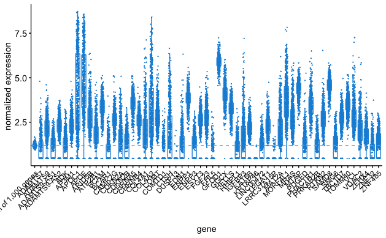

```r
  ggsave(filename = paste0(PLOT_loc, "/", Today, ".TargetExpression_vs_1000genes.pdf"), plot = last_plot())
```

```r
  rm(p1 )
```

## 6.5 Genes of interest vs. clinical and plaque traits

```r
# create long df, containing one column for all numerical plaque phenotypes, one column for all categorical phenotypes, and one for the genes of interest

expression_long_cat <- expression_long %>%
  pivot_longer(cols = plaque_phenotypes_cat, names_to = "plaque_phenotype", values_to = "levels") %>%
  mutate(levels = factor(levels, levels = c("no/minor", "moderate/heavy",
                                            " <10%", " >10%",
                                            "<40%", ">40%",
                                            "no", "yes"))) # turn factor, and order factor levels for plotting
```

```
pivot_longer: reorganized (Macrophages.bin, SMC.bin, Calc.bin, Collagen.bin, Fat.bin_10, …) into (plaque_phenotype, levels) [was 34832x22, now 243824x17]
mutate: no changes
```

```r
expression_long_num <- expression_long %>%
  pivot_longer(cols = plaque_phenotypes_num, names_to = "plaque_phenotype", values_to = "value")
```

```
pivot_longer: reorganized (MAC_rankNorm, SMC_rankNorm, MastCells_rankNorm, Neutrophils_rankNorm, VesselDensity_rankNorm) into (plaque_phenotype, value) [was 34832x22, now 174160x19]
```

### 6.5.1 Plaque phenotypes

We correlated the categorical plaque characteristics to gene expression.

**Figure 4: genes of interest plotted over plaque phenotype levels**

```r
# Make directory for plots
ifelse(!dir.exists(file.path(QC_loc, "/PlaquePhenotypes")),
       dir.create(file.path(QC_loc, "/PlaquePhenotypes")),
       FALSE)
```

```
[1] FALSE
```

```r
PLAQUEPHENO_loc = paste0(QC_loc,"/PlaquePhenotypes")

for(GENE in target_genes_qc){
  cat(paste0("Plotting expression for ", GENE,".\n"))
  temp <- subset(expression_long_cat, symbol == GENE)
  p1 <- ggpubr::ggboxplot(temp,
                          x = "plaque_phenotype",
                          y = "expression_value",
                          color = "levels",
                          palette = "npg",
                          add = "jitter",
                          add.params = list(size = 0.1, jitter = 0.2),
                          ylab = paste0("normalized expression ", GENE,"" )
                          )
  # print(p1)
  cat(paste0("Saving image for ", GENE,".\n"))
  ggsave(filename = paste0(PLAQUEPHENO_loc, "/", Today, ".",GENE,".expression_vs_cat_plaquephenotypes.png"), plot = last_plot())
  ggsave(filename = paste0(PLAQUEPHENO_loc, "/", Today, ".",GENE,".expression_vs_cat_plaquephenotypes.pdf"), plot = last_plot())

  rm(temp, p1 )
}
```

```
Plotting expression for ADAMTS7.
Saving image for ADAMTS7.
```

```
Plotting expression for ADAMTS9.
Saving image for ADAMTS9.
Plotting expression for ADAMTS9-AS1.
Saving image for ADAMTS9-AS1.
Plotting expression for ADAMTS9-AS2.
Saving image for ADAMTS9-AS2.
Plotting expression for ADK.
Saving image for ADK.
Plotting expression for AP3M1.
Saving image for AP3M1.
Plotting expression for APOC1.
Saving image for APOC1.
Plotting expression for APOE.
Saving image for APOE.
Plotting expression for ARID5B.
Saving image for ARID5B.
Plotting expression for ATP2B1.
Saving image for ATP2B1.
Plotting expression for BCAM.
Saving image for BCAM.
Plotting expression for BCAR1.
Saving image for BCAR1.
Plotting expression for CAMK2G.
Saving image for CAMK2G.
Plotting expression for CDKN2A.
Saving image for CDKN2A.
Plotting expression for CDKN2B.
Saving image for CDKN2B.
Plotting expression for CHRNA5.
Saving image for CHRNA5.
Plotting expression for CHRNB4.
Saving image for CHRNB4.
Plotting expression for COL4A1.
Saving image for COL4A1.
Plotting expression for COL4A2.
Saving image for COL4A2.
Plotting expression for COMT.
Saving image for COMT.
Plotting expression for COMTD1.
Saving image for COMTD1.
```

[output cut: 55 more lines]

```
Saving image for SMG6.
Plotting expression for TBC1D7.
Saving image for TBC1D7.
Plotting expression for TOMM40.
Saving image for TOMM40.
Plotting expression for VCL.
Saving image for VCL.
Plotting expression for VDAC2.
Saving image for VDAC2.
Plotting expression for ZFHX4.
Saving image for ZFHX4.
Plotting expression for ZNF32.
Saving image for ZNF32.
Plotting expression for ZNF485.
Saving image for ZNF485.
```

### 6.5.2 Clinical traits

We correlated secondary major adverse clinical events (MACE) to gene expression.

**Figure 5: genes of interest plotted over MACE**

```r
# Make directory for plots
ifelse(!dir.exists(file.path(QC_loc, "/ClinicalOutcome")),
       dir.create(file.path(QC_loc, "/ClinicalOutcome")),
       FALSE)
```

```
[1] FALSE
```

```r
CLINICALOUT_loc = paste0(QC_loc,"/ClinicalOutcome")

# Make directory for plots
ifelse(!dir.exists(file.path(CLINICALOUT_loc, "/30Days")),
       dir.create(file.path(CLINICALOUT_loc, "/30Days")),
       FALSE)
```

```
[1] FALSE
```

```r
CLINICAL30D_loc = paste0(CLINICALOUT_loc,"/30Days")

# Make directory for plots
ifelse(!dir.exists(file.path(CLINICALOUT_loc, "/3Years")),
       dir.create(file.path(CLINICALOUT_loc, "/3Years")),
       FALSE)
```

```
[1] FALSE
```

```r
CLINICAL3Y_loc = paste0(CLINICALOUT_loc,"/3Years")


for(GENE in target_genes_qc){
  cat(paste0("Plotting expression for ", GENE,".\n"))
  temp <- subset(expression_long, symbol == GENE & !is.na(epmajor.30days))
  p1 <- ggpubr::ggboxplot(temp,
                          x = "epmajor.30days",
                          y = "expression_value",
                          color = "epmajor.30days",
                          palette = "npg",
                          add = "jitter",
                          add.params = list(size = 0.1, jitter = 0.2),
                          ylab = paste0("normalized expression ", GENE,"" )
                          )
  # print(p1)
  cat(paste0("Saving image for ", GENE,".\n"))
  ggsave(filename = paste0(CLINICAL30D_loc, "/", Today, ".",GENE,".expression_vs_MACE_30days.png"), plot = last_plot())
  ggsave(filename = paste0(CLINICAL30D_loc, "/", Today, ".",GENE,".expression_vs_MACE_30days.pdf"), plot = last_plot())

  rm(temp, p1 )
}
```

```
Plotting expression for ADAMTS7.
Saving image for ADAMTS7.
```

```
Plotting expression for ADAMTS9.
Saving image for ADAMTS9.
Plotting expression for ADAMTS9-AS1.
Saving image for ADAMTS9-AS1.
Plotting expression for ADAMTS9-AS2.
Saving image for ADAMTS9-AS2.
Plotting expression for ADK.
Saving image for ADK.
Plotting expression for AP3M1.
Saving image for AP3M1.
Plotting expression for APOC1.
Saving image for APOC1.
Plotting expression for APOE.
Saving image for APOE.
Plotting expression for ARID5B.
Saving image for ARID5B.
Plotting expression for ATP2B1.
Saving image for ATP2B1.
Plotting expression for BCAM.
Saving image for BCAM.
Plotting expression for BCAR1.
Saving image for BCAR1.
Plotting expression for CAMK2G.
Saving image for CAMK2G.
Plotting expression for CDKN2A.
Saving image for CDKN2A.
Plotting expression for CDKN2B.
Saving image for CDKN2B.
Plotting expression for CHRNA5.
Saving image for CHRNA5.
Plotting expression for CHRNB4.
Saving image for CHRNB4.
Plotting expression for COL4A1.
Saving image for COL4A1.
Plotting expression for COL4A2.
Saving image for COL4A2.
Plotting expression for COMT.
Saving image for COMT.
Plotting expression for COMTD1.
Saving image for COMTD1.
```

[output cut: 55 more lines]

```
Saving image for SMG6.
Plotting expression for TBC1D7.
Saving image for TBC1D7.
Plotting expression for TOMM40.
Saving image for TOMM40.
Plotting expression for VCL.
Saving image for VCL.
Plotting expression for VDAC2.
Saving image for VDAC2.
Plotting expression for ZFHX4.
Saving image for ZFHX4.
Plotting expression for ZNF32.
Saving image for ZNF32.
Plotting expression for ZNF485.
Saving image for ZNF485.
```

```r
for(GENE in target_genes_qc){
  cat(paste0("Plotting expression for ", GENE,".\n"))
  temp <- subset(expression_long, symbol == GENE & !is.na(epmajor.3years))
  p1 <- ggpubr::ggboxplot(temp,
                          x = "epmajor.3years",
                          y = "expression_value",
                          color = "epmajor.3years",
                          palette = "npg",
                          add = "jitter",
                          add.params = list(size = 0.1, jitter = 0.2),
                          ylab = paste0("normalized expression ", GENE,"" )
                          )
  # print(p1)
  cat(paste0("Saving image for ", GENE,".\n"))
  ggsave(filename = paste0(CLINICAL3Y_loc, "/", Today, ".",GENE,".expression_vs_MACE_3years.png"), plot = last_plot())
  ggsave(filename = paste0(CLINICAL3Y_loc, "/", Today, ".",GENE,".expression_vs_MACE_3years.pdf"), plot = last_plot())

  rm(temp, p1 )
}
```

```
Plotting expression for ADAMTS7.
Saving image for ADAMTS7.
Plotting expression for ADAMTS9.
Saving image for ADAMTS9.
Plotting expression for ADAMTS9-AS1.
Saving image for ADAMTS9-AS1.
Plotting expression for ADAMTS9-AS2.
Saving image for ADAMTS9-AS2.
Plotting expression for ADK.
Saving image for ADK.
Plotting expression for AP3M1.
Saving image for AP3M1.
Plotting expression for APOC1.
Saving image for APOC1.
Plotting expression for APOE.
Saving image for APOE.
Plotting expression for ARID5B.
Saving image for ARID5B.
Plotting expression for ATP2B1.
Saving image for ATP2B1.
Plotting expression for BCAM.
Saving image for BCAM.
Plotting expression for BCAR1.
Saving image for BCAR1.
Plotting expression for CAMK2G.
Saving image for CAMK2G.
Plotting expression for CDKN2A.
Saving image for CDKN2A.
Plotting expression for CDKN2B.
Saving image for CDKN2B.
Plotting expression for CHRNA5.
Saving image for CHRNA5.
Plotting expression for CHRNB4.
Saving image for CHRNB4.
Plotting expression for COL4A1.
Saving image for COL4A1.
Plotting expression for COL4A2.
Saving image for COL4A2.
Plotting expression for COMT.
Saving image for COMT.
```

[output cut: 57 more lines]

```
Saving image for SMG6.
Plotting expression for TBC1D7.
Saving image for TBC1D7.
Plotting expression for TOMM40.
Saving image for TOMM40.
Plotting expression for VCL.
Saving image for VCL.
Plotting expression for VDAC2.
Saving image for VDAC2.
Plotting expression for ZFHX4.
Saving image for ZFHX4.
Plotting expression for ZNF32.
Saving image for ZNF32.
Plotting expression for ZNF485.
Saving image for ZNF485.
```

#### 6.5.2.1 Statistical testing: non-parametric test

Since we have multiple groups, while data and residuals are not normally distributed, we need to use a Kruskal-Wallis test. The assumptions here are independent samples (yes), and homoscedasticity (yes). No assumption that the data or residuals have a known distribution.

```r
var_pairs <- crossing(target_genes_qc, c(plaque_phenotypes_cat, "epmajor.3years")) %>%
  setNames(c("genes", "variables"))

d <- expression_wide %>%
  dplyr::select(target_genes_qc, plaque_phenotypes_cat, epmajor.3years)

kw_results <- var_pairs %>%
  dplyr::mutate(r.test = purrr::map2(genes, variables, ~ stats::kruskal.test(d[[.x]], d[[.y]])),
                r.test = purrr::map(r.test, broom::tidy)) %>%
  tidyr::unnest(r.test) %>%
  mutate(padj = p.adjust(p.value, method = "holm"))
```

```
mutate: new variable 'padj' (double) with 4 unique values and 0% NA
```

```r
DT::datatable(kw_results)
```

|  | genes | variables | statistic | p.value | parameter | method | padj |
| --- | --- | --- | --- | --- | --- | --- | --- |
| 1 | ADAMTS7 | Calc.bin | 1.71752879646721 | 0.190011454117684 | 1 | Kruskal-Wallis rank sum test | 1 |
| 2 | ADAMTS7 | Collagen.bin | 1.16800798294024 | 0.279810924712671 | 1 | Kruskal-Wallis rank sum test | 1 |
| 3 | ADAMTS7 | epmajor.3years | 0.0894472085404139 | 0.764881095144518 | 1 | Kruskal-Wallis rank sum test | 1 |
| 4 | ADAMTS7 | Fat.bin_10 | 13.7981201640161 | 0.000203539782875329 | 1 | Kruskal-Wallis rank sum test | 0.0911858227281475 |
| 5 | ADAMTS7 | Fat.bin_40 | 2.52581817975936 | 0.111996676485353 | 1 | Kruskal-Wallis rank sum test | 1 |
| 6 | ADAMTS7 | IPH.bin | 0.285681667378452 | 0.59300120274528 | 1 | Kruskal-Wallis rank sum test | 1 |
| 7 | ADAMTS7 | Macrophages.bin | 4.33197232646397 | 0.0374028813641231 | 1 | Kruskal-Wallis rank sum test | 1 |
| 8 | ADAMTS7 | SMC.bin | 0.169310508607744 | 0.680725308769163 | 1 | Kruskal-Wallis rank sum test | 1 |
| 9 | ADAMTS9 | Calc.bin | 0.819512838815497 | 0.365322638807443 | 1 | Kruskal-Wallis rank sum test | 1 |
| 10 | ADAMTS9 | Collagen.bin | 0.000458518841207242 | 0.982916161120084 | 1 | Kruskal-Wallis rank sum test | 1 |

[output cut: 438 more lines]

```r
fwrite(kw_results, file = paste0(OUT_loc,"/",Today,".results.kruskal_wallis.gene_vs_plaque_clin_traits.txt"))
```

### 6.5.3 plaque phenotypes: numerical variables

**Figure 6: genes of interest plotted over plaque phenotype numbers**

```r
# Make directory for plots
ifelse(!dir.exists(file.path(PLAQUEPHENO_loc, "/Correlations")),
       dir.create(file.path(PLAQUEPHENO_loc, "/Correlations")),
       FALSE)
```

```
[1] TRUE
```

```r
PLAQUEPHENOCOR_loc = paste0(PLAQUEPHENO_loc,"/Correlations")

for(GENE in target_genes_qc){
  cat(paste0("Plotting expression for ", GENE,".\n"))
  temp <- subset(expression_long_num, symbol == GENE)
  p1 <- ggpubr::ggscatter(temp,
                          x = "value",
                          y = "expression_value",
                          color = "plaque_phenotype",
                          palette = "npg",
                          facet.by = "plaque_phenotype",
                          add = "reg.line",
                          add.params = list(linetype = "dotted", color = uithof_color[30]),
                          conf.int = TRUE,
                          cor.coef = TRUE, cor.method = "spearman",
                          ylab = paste0("normalized expression ", GENE,"" )
                          )

  # print(p1)
  cat(paste0("Saving image for ", GENE,".\n"))
  ggsave(filename = paste0(PLAQUEPHENOCOR_loc, "/", Today, ".",GENE,".expression_vs_quant_plaque_traits.png"), plot = last_plot())
  ggsave(filename = paste0(PLAQUEPHENOCOR_loc, "/", Today, ".",GENE,".expression_vs_quant_plaque_traits.pdf"), plot = last_plot())

  rm(temp, p1 )
}
```

```
Plotting expression for ADAMTS7.
Saving image for ADAMTS7.
```

```
Plotting expression for ADAMTS9.
Saving image for ADAMTS9.
Plotting expression for ADAMTS9-AS1.
Saving image for ADAMTS9-AS1.
Plotting expression for ADAMTS9-AS2.
Saving image for ADAMTS9-AS2.
Plotting expression for ADK.
Saving image for ADK.
Plotting expression for AP3M1.
Saving image for AP3M1.
Plotting expression for APOC1.
Saving image for APOC1.
Plotting expression for APOE.
Saving image for APOE.
Plotting expression for ARID5B.
Saving image for ARID5B.
Plotting expression for ATP2B1.
Saving image for ATP2B1.
Plotting expression for BCAM.
Saving image for BCAM.
Plotting expression for BCAR1.
Saving image for BCAR1.
Plotting expression for CAMK2G.
Saving image for CAMK2G.
Plotting expression for CDKN2A.
Saving image for CDKN2A.
Plotting expression for CDKN2B.
Saving image for CDKN2B.
Plotting expression for CHRNA5.
Saving image for CHRNA5.
Plotting expression for CHRNB4.
Saving image for CHRNB4.
Plotting expression for COL4A1.
Saving image for COL4A1.
Plotting expression for COL4A2.
Saving image for COL4A2.
Plotting expression for COMT.
Saving image for COMT.
Plotting expression for COMTD1.
Saving image for COMTD1.
```

[output cut: 55 more lines]

```
Saving image for SMG6.
Plotting expression for TBC1D7.
Saving image for TBC1D7.
Plotting expression for TOMM40.
Saving image for TOMM40.
Plotting expression for VCL.
Saving image for VCL.
Plotting expression for VDAC2.
Saving image for VDAC2.
Plotting expression for ZFHX4.
Saving image for ZFHX4.
Plotting expression for ZNF32.
Saving image for ZNF32.
Plotting expression for ZNF485.
Saving image for ZNF485.
```

#### 6.5.3.1 Statistical testing: correlation

If we calculate the correlation coefficients and corresponding p-values for these correlations, we get the following dataframe. Correlation method used in this case is Spearman’s, since the genes in most case are not nicely normally distributed.

```r
var_pairs <- crossing(target_genes_qc, plaque_phenotypes_num) %>%
  setNames(c("genes", "plaque_phenotype"))

d <- expression_wide %>%
  dplyr::select(target_genes_qc, plaque_phenotypes_num)

corr_results <- var_pairs %>%
  dplyr::mutate(r.test = purrr::map2(genes, plaque_phenotype, ~ stats::cor.test(d[[.x]], d[[.y]], method = "spearman")),
                r.test = purrr::map(r.test, broom::tidy)) %>%
  tidyr::unnest(r.test) %>%
  mutate(padj = p.adjust(p.value, method = "holm"))

DT::datatable(corr_results)
```

|  | genes | plaque_phenotype | estimate | statistic | p.value | method | alternative | padj |
| --- | --- | --- | --- | --- | --- | --- | --- | --- |
| 1 | ADAMTS7 | MAC_rankNorm | -0.000417406822859383 | 37290214.6957341 | 0.99181176633242 | Spearman's rank correlation rho | two.sided | 1 |
| 2 | ADAMTS7 | MastCells_rankNorm | 0.020012371282246 | 158463.999563661 | 0.844131664699019 | Spearman's rank correlation rho | two.sided | 1 |
| 3 | ADAMTS7 | Neutrophils_rankNorm | 0.0676471981216658 | 174778.856240113 | 0.495041024485994 | Spearman's rank correlation rho | two.sided | 1 |
| 4 | ADAMTS7 | SMC_rankNorm | -0.114406469573858 | 41129867.6232796 | 0.00484046177794414 | Spearman's rank correlation rho | two.sided | 1 |
| 5 | ADAMTS7 | VesselDensity_rankNorm | 0.00855936000889566 | 30440439.9154005 | 0.838566584803977 | Spearman's rank correlation rho | two.sided | 1 |
| 6 | ADAMTS9 | MAC_rankNorm | -0.0241715443248585 | 38175641.9996978 | 0.552256245642829 | Spearman's rank correlation rho | two.sided | 1 |
| 7 | ADAMTS9 | MastCells_rankNorm | -0.11583238826749 | 180430.097182853 | 0.253566929588334 | Spearman's rank correlation rho | two.sided | 1 |
| 8 | ADAMTS9 | Neutrophils_rankNorm | 0.0206720316610077 | 183584.820944827 | 0.835003722321363 | Spearman's rank correlation rho | two.sided | 1 |
| 9 | ADAMTS9 | SMC_rankNorm | 0.0653820490050992 | 34494337.2569082 | 0.108146698395511 | Spearman's rank correlation rho | two.sided | 1 |
| 10 | ADAMTS9 | VesselDensity_rankNorm | -0.0221815585788025 | 31384285.716619 | 0.597489533181594 | Spearman's rank correlation rho | two.sided | 1 |

[output cut: 270 more lines]

```r
fwrite(corr_results, file = paste0(OUT_loc,"/",Today,".results.spearman.gene_vs_plaque_clin_traits.txt"))
```

### 6.5.4 Heatmaps for plaque phenotypes, secondary events, and genes of interest

Note that we removed *DUPD1* given that it’s standard deviation = 0.

**Figure 7: correlation heatmap between expression of plaque phenotypes, secondary events (epmajor), and genes of interest**

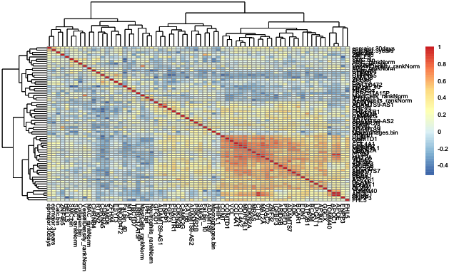

```r
library(tidyverse)
library(magrittr)

# dplyr::select(MAC_rankNorm, SMC_rankNorm, VesselDensity_rankNorm, epmajor.30days, epmajor.3years, target_genes_qc) %>%
temp <- expression_wide %>%
  column_to_rownames("study_number") %>%
  dplyr::select(plaque_phenotypes_cat, plaque_phenotypes_num, epmajor.30days, epmajor.3years, target_genes_qc) %>%
  drop_na() %>% # drop NA
  mutate(across(all_of(plaque_phenotypes_cat), as.numeric)) %>% # convert factors to numeric
  Filter(function(x) sd(x) != 0, .) # filter variables with sd = 0

temp.cor <- cor(temp, method = "spearman")

p1 <- pheatmap(data.matrix(temp.cor),
               scale = "none",
               cluster_rows = TRUE,
               cluster_cols = TRUE,
               legend = TRUE,
               fontsize = 7)

p1
```

```r
ggsave(filename = paste0(PLOT_loc, "/", Today, ".correlations.pdf"), plot = p1, height = 15, width = 15)

ggsave(filename = paste0(PLOT_loc, "/", Today, ".correlations.png"), plot = p1, height = 15, width = 15)

rm(temp, temp.cor, p1)
```

**Figure 8: correlation heatmap between expression of genes of interest**

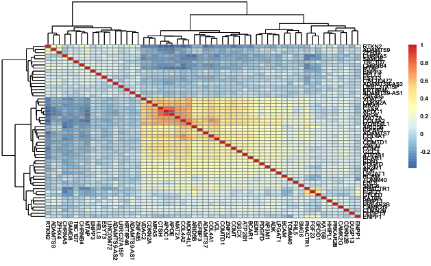

```r
library(tidyverse)
library(magrittr)

temp <- expression_wide %>%
  column_to_rownames("study_number") %>%
  dplyr::select(target_genes_qc) %>%
  drop_na() %>% # drop NA
  Filter(function(x) sd(x) != 0, .) # filter variables with sd = 0

temp.cor <- cor(temp, method = "spearman")

p1 <- pheatmap(data.matrix(temp.cor),
               scale = "none",
               cluster_rows = TRUE,
               cluster_cols = TRUE,
               legend = TRUE,
               fontsize = 7)
p1
```

```r
ggsave(filename = paste0(PLOT_loc, "/", Today, ".correlations.target_genes.pdf"), plot = p1, height = 15, width = 15)

ggsave(filename = paste0(PLOT_loc, "/", Today, ".correlations.target_genes.png"), plot = p1, height = 15, width = 15)


rm(temp, temp.cor, p1)
```

### 6.5.5 Plaque vulnerability index

**Figure 9: genes of interest plotted over plaque vulnerability index**

```r
# Make directory for plots
ifelse(!dir.exists(file.path(QC_loc, "/PlaqueVulnerabilityIndex")),
       dir.create(file.path(QC_loc, "/PlaqueVulnerabilityIndex")),
       FALSE)
PVI_loc = paste0(QC_loc,"/PlaqueVulnerabilityIndex")

# gather expression_data_sel df into long df form for annotation, plotting and statistics
expression_long_PVI <-
     gather(expression_data_sel, key = "study_number", value = "expression_value", -c(gene_ensembl, symbol))

# old school way
# Annotate with smoking variables
# sample_ids <- expression_long$study_number
# mm <- match(expression_long$study_number, rownames(colData(vsd)))
#
# ## Add traits to df
# ## Binary traits
# expression_long$sex <- colData(vsd)$sex[mm]
# expression_long$testosterone <- colData(vsd)$testosterone[mm]
# expression_long$t_e2_ratio <- colData(vsd)$t_e2_ratio[mm]

# new school way
plaque_phenotypes_PVI <- c("Plaque_Vulnerability_Index")

expression_long_PVI <- expression_long_PVI %>%
  left_join(bulkRNA_meta_clin %>% dplyr::select(study_number,
                                       plaque_phenotypes_PVI,
                                       Gender, Hospital),
            by = "study_number")
head(expression_long_PVI)
unique(expression_long_PVI$Plaque_Vulnerability_Index)

expression_long_PVI <- expression_long_PVI %>%
  pivot_longer(cols = plaque_phenotypes_PVI,
               names_to = "Plaque_Vulnerability_Index",
               values_to = "levels") %>%
  mutate(levels = factor(levels, levels = c("0", "1", "2", "3", "4", "5"))) # turn factor, and order factor levels for plotting

for(GENE in target_genes_qc){
  cat(paste0("Plotting expression for ", GENE,".\n"))
  temp <- subset(expression_long_PVI, symbol == GENE)
  p1 <- ggpubr::ggboxplot(temp,
                          x = "levels",
                          y = "expression_value",
                          color = "levels", #fill = "levels",
                          palette = "npg",
                          add = "jitter",
                          add.params = list(size = 1.5, jitter = 0.3),
                          xlab = "plaque vulnerability index",
                          ylab = paste0("normalized expression ", GENE,"" )
                          )
  # print(p1)

  p2 <- ggpubr::ggboxplot(temp,
                          x = "levels",
                          y = "expression_value",
                          color = "Gender", #fill = "Gender",
                          palette = "npg",
                          add = "jitter",
                          add.params = list(size = 1.5, jitter = 0.3),
                          xlab = "plaque vulnerability index",
                          ylab = paste0("normalized expression ", GENE,"" )
                          )
  # print(p2)

  cat(paste0("Saving image for ", GENE,".\n"))
  ggsave(filename = paste0(PVI_loc, "/", Today, ".",GENE,".expression_vs_plaquevulnerabilityindex.png"), plot = p1)
  ggsave(filename = paste0(PVI_loc, "/", Today, ".",GENE,".expression_vs_plaquevulnerabilityindex.pdf"), plot = p1)

  cat(paste0("Saving image for ", GENE,", sex-stratified.\n"))
  ggsave(filename = paste0(PVI_loc, "/", Today, ".",GENE,".expression_vs_plaquevulnerabilityindex.sex.png"), plot = p2)
  ggsave(filename = paste0(PVI_loc, "/", Today, ".",GENE,".expression_vs_plaquevulnerabilityindex.sex.pdf"), plot = p2)

  rm(temp, p1 )

}
```

**Figure 10: correlation heatmap between plaque vulnerability index, and genes of interest**

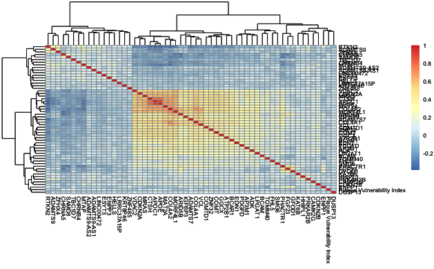

```r
library(tidyverse)
library(magrittr)

expression_wide_PVI <- expression_long_PVI %>%
  dplyr::select(-gene_ensembl) %>%
  spread(key = symbol, value = expression_value)

temp <- expression_wide_PVI %>%
  column_to_rownames("study_number") %>%
  dplyr::select("levels", target_genes_qc) %>%
  drop_na() %>% # drop NA
  mutate(across(all_of("levels"), as.numeric)) #%>% # convert factors to numeric
  # Filter(function(x) sd(x) != 0, .) # filter variables with sd = 0
# str(temp)

# Rename column where names is "Sepal.Length"
names(temp)[names(temp) == "levels"] <- "Plaque Vulnerability Index"
# dim(temp)

temp.cor <- cor(temp, method = "spearman")

p1 <- pheatmap(data.matrix(temp.cor),
               scale = "none",
               cluster_rows = TRUE,
               cluster_cols = TRUE,
               legend = TRUE,
               fontsize = 7)

p1
```

```r
ggsave(filename = paste0(PLOT_loc, "/", Today, ".correlations.PVI.pdf"), plot = p1, height = 15, width = 15)

ggsave(filename = paste0(PLOT_loc, "/", Today, ".correlations.PVI.png"), plot = p1, height = 15, width = 15)

rm(temp, temp.cor, p1)
```

```r
var_pairs <- crossing(target_genes_qc, c("Plaque Vulnerability Index")) %>%
  setNames(c("genes", "variables"))

d <- expression_wide_PVI %>%
  dplyr::select(target_genes_qc, "levels") #%>%
 # mutate(across(all_of("levels"), as.numeric)) #%>% # convert factors to numeric

names(d)[names(d) == "levels"] <- "Plaque Vulnerability Index"

kw_results_PVI <- var_pairs %>%
  dplyr::mutate(r.test = purrr::map2(genes, variables, ~ stats::kruskal.test(d[[.x]], d[[.y]])),
                r.test = purrr::map(r.test, broom::tidy)) %>%
  tidyr::unnest(r.test) %>%
  mutate(padj = p.adjust(p.value, method = "holm"))

DT::datatable(kw_results_PVI)
```

|  | genes | variables | statistic | p.value | parameter | method | padj |
| --- | --- | --- | --- | --- | --- | --- | --- |
| 1 | ADAMTS7 | Plaque Vulnerability Index | 13.9974549236554 | 0.0156255908449901 | 5 | Kruskal-Wallis rank sum test | 0.875033087319448 |
| 2 | ADAMTS9 | Plaque Vulnerability Index | 6.78393448085852 | 0.23721166489583 | 5 | Kruskal-Wallis rank sum test | 1 |
| 3 | ADAMTS9-AS1 | Plaque Vulnerability Index | 3.23861278091993 | 0.6632523381894 | 5 | Kruskal-Wallis rank sum test | 1 |
| 4 | ADAMTS9-AS2 | Plaque Vulnerability Index | 1.83846139137345 | 0.871014865930915 | 5 | Kruskal-Wallis rank sum test | 1 |
| 5 | ADK | Plaque Vulnerability Index | 4.87590061887784 | 0.431212574938281 | 5 | Kruskal-Wallis rank sum test | 1 |
| 6 | AP3M1 | Plaque Vulnerability Index | 2.65475487489575 | 0.753029300133796 | 5 | Kruskal-Wallis rank sum test | 1 |
| 7 | APOC1 | Plaque Vulnerability Index | 6.83732325500123 | 0.233022642487845 | 5 | Kruskal-Wallis rank sum test | 1 |
| 8 | APOE | Plaque Vulnerability Index | 5.9630791610217 | 0.309828073340891 | 5 | Kruskal-Wallis rank sum test | 1 |
| 9 | ARID5B | Plaque Vulnerability Index | 4.99796822642911 | 0.416128198109727 | 5 | Kruskal-Wallis rank sum test | 1 |
| 10 | ATP2B1 | Plaque Vulnerability Index | 8.22953604718358 | 0.144030920868503 | 5 | Kruskal-Wallis rank sum test | 1 |

[output cut: 46 more lines]

```r
fwrite(kw_results_PVI, file = paste0(OUT_loc,"/",Today,".results.kruskal_wallis.gene_vs_PVI.txt"))
```

# 7 Gene target list

We are saving the final list of genes of interest

```r
temp <- subset(expression_data_sel, select = c("gene_ensembl", "symbol"))

fwrite(temp,
       file = paste0(OUT_loc, "/", Today, ".target_list.qc.txt"),
       sep = " ", row.names = FALSE, col.names = TRUE,
       showProgress = TRUE)
rm(temp)
```

# 8 Session information

```
Version:      v1.0.5
Last update:  2021-03-11
Written by:   Sander W. van der Laan (s.w.vanderlaan-2[at]umcutrecht.nl).
Description:  Script to load bulk RNA sequencing data, and perform gene expression analyses, and visualisations.
Minimum requirements: R version 3.5.2 (2018-12-20) -- 'Eggshell Igloo', macOS Mojave (10.14.2).

**MoSCoW To-Do List**
The things we Must, Should, Could, and Would have given the time we have.
_M_

_S_

_C_

_W_


**Changes log**
* v1.0.5 Update to the gene list.
* v1.0.4 Add correlation analysis and heatmap for plaque vulnerability index.
* v1.0.3 Add gene expression as a function of plaque vulnerability index.
* v1.0.2 Filter samples based on artery operated (CEA) and informed consent.
* v1.0.1 Added heatmap of correlation between target genes.
* v1.0.0 Inital version.
```

# 9 Saving environment

```r
save.image(paste0(PROJECT_loc, "/",Today,".",PROJECTNAME,".results.RData"))
```

| <sup>© 1979-2021 Sander W. van der Laan \| s.w.vanderlaan-2[at]umcutrecht.nl \| swvanderlaan.github.io.</sup> |
| --- |